# 智能制造系统设计 · 第 2 讲：质量工程（二）与质量工具

刘训臣

山东科技大学 机械电子工程学院

# 第〇部分 · 课程介绍与本讲定位

- 第 1 讲回顾与教学进度：本讲是第 2 讲
- 本讲路线图与工具链全景：四个内容块、五个工具、一个指数
- 伦理落点与 90 分钟安排：质量工具是对社会的承诺；时间表、四步练法与验收标准
- **主线**：工具 → 数据 → 判读 → 责任

## 第 1 讲回顾与检查：五个问题自测

> **合上讲义，4 分钟答完五问；答不出的那一条，就是今天要补的地基缺口。**

| 问题 | 一句话答案 | 落点 |
| --- | --- | --- |
| ① 质量是什么 | 固有特性满足明确或隐含需求的程度；价格、交期属赋予特性 | 质量定义 |
| ② 七项原则是哪七条 | 顾客、领导、全员、过程方法、改进、循证决策、关系管理 | 体系内核 |
| ③ 凯悦案怎么坏的 | 吊杆连接变更使节点荷载由 89 kN 增到 178 kN，超过 133 kN 承载力 | 事故案例 |
| ④ 责任怎么判 | 查规范 → 定义务 → 查因果 → 定责任 | 责任判定 |
| ⑤ ISO 9000 族四个标准各管什么 | 9000 词典、9001 及格线、9004 提高线、19011 考法；只有 9001 可认证 | 标准体系 |

- 几个数字要能当场报准：114 人死亡、216 人受伤，89、178、133 kN，民事赔偿约 1.4 亿美元
- 第 ③④ 问的”预见与责任”就是今天 FMEA、SPC 要接的伦理主线

## 教学进度 · 10 次课全览

| 次 | 模块 | 主题 |
| --- | --- | --- |
| 1 | 模块 1 与 3.1 | 课程导论、工程与社会与质量工程（一）：国家战略、工程的社会属性、质量管理基础 |
| **2** | **3.1** | **质量工程（二）与质量工具：五大工具 APQP／FMEA／MSA／SPC／PPAP、Cpk、QC 七大手法** |
| 3 | 3.2 | 工业工程与精益生产（＋实验 2 课时：线性规划与工业工程例子） |
| 4 | 3.3、3.4 | 安全工程与环保工程：海因里希法则、事故树 FTA、风险评估、三废治理、双碳 |
| 5 | 3.5、3.6 | 成本管理与人力资源：成本构成、投资回收期、NPV／IRR、质量成本、人才与激励 |
| 6 | 4.1～4.3 | 企业信息系统（一）：ERP、MES、PLM 与系统集成全景 |
| 7 | 4 | 企业信息系统（二）与 8D：CRM／WMS／APS，8D 八步与软件开发流程 |
| 8 | 工程与社会与工程伦理（一） | 工程事故与伦理准则：凯悦酒店、NSPE 准则、伦理决策框架 |
| 9 | 工程与社会与工程伦理（二） | 风险、安全与责任，工程师与组织：责任判定、组织文化与信任 |
| 10 | 工程与社会与工程伦理（三）与综合 | 技术的社会意义、国际化、AI 伦理；智能设计应用、前沿、课程设计与总复习 |

## 本讲路线图：四个内容块与一条伦理主线

> **框架 → 风险 → 数据 → 手法：前一个内容块的输出就是后一个内容块的输入。**

| 内容块 | 入口问题 | 讲什么 | 出口结论 |
| --- | --- | --- | --- |
| 一 | 质量怎么在项目里被安排 | 五工具分工与接口、APQP 五阶段、控制计划 | 质量是策划出来的 |
| 二 | 会怎么坏、数据可信吗 | S／O／D 与 RPN／AP、GR&R 三档、18 项证据 | 风险要排序，放行要证据 |
| 三 | 过程稳不稳、能力够不够 | 判异八准则、X̄–R 算例、Cpk 判读与 ppm | 先受控，再谈能力 |
| 四 | 原因在哪、能抽检吗、能用多久 | 七种图分工、AQL 与 OC 曲线、浴盆曲线 | 按问题阶段选工具 |

- 四块的接口：FMEA 定高风险项 → 控制计划定监控对象 → SPC 监视 → 七手法查因
- **伦理主线**：FMEA 的每一个 S＝10 都是承诺，SPC 判异是诚实面对数据；第五部分留 2 分钟讨论
- 每块末一页”推导留给 AI”，全讲共 5 页，课后按名单抽查

## 质量工具链全景：五大工具、七手法、抽样与可靠性

> **一条链：策划 → 预防 → 测量 → 控制 → 放行；两条支线是七大手法与抽样／可靠性。**

| 层 | 工具 | 回答的问题 |
| --- | --- | --- |
| 策划层 | APQP & CP | 什么时候、由谁、按什么计划把质量做进去 |
| 预防层 | FMEA | 会怎么坏、后果多重、先防哪一个 |
| 保证层 | MSA → SPC → PPAP | 数据可信吗、过程稳吗、能不能放行 |
| 改进层 | QC 七大手法 | 问题在哪、原因是什么、分布与趋势如何 |
| 寿命层 | 抽样检验与可靠性 | 这批收不收；能用多久、什么时候开始坏 |

- 顺序不是偏好：FMEA 认定的高风险项进控制计划，SPC 才有监控对象
- MSA 不过关，SPC 的数据就不可信——测量分析必须排在统计控制之前
- 七手法、抽样与可靠性是两条支线：一个查因、一个判批、一个管寿命，不占体系位置

## 学习目标：四条能力与验收标准

> **四条是递进的：算得出 → 判得准 → 选得对 → 问得到人。**

| 能力 | 具体要求 | 怎么验收 | 对应内容块 |
| --- | --- | --- | --- |
| 会算 | Cpk（含 Ca 分解）、RPN、GR&R 百分比 | 10 个数据算出 Cpk，三位小数对得上 | 内容块 2、3 |
| 会判 | Cpk 三档、判异八准则、GR&R 三档、PPAP 证据是否齐 | 给一组数据与一张图，说出结论与下一步 | 内容块 2、3 |
| 会用 | 七大手法各自回答什么问题、什么时候选哪张图 | 对一个现场问题选两种手法并说明理由 | 内容块 4 |
| 会问 | 谁签的字、数据谁测的、S 为什么取 9 | 每次讨论提一个责任归属问题 | 全讲 |

- **承上**：第 1 讲给了质量的定义、七项原则与 QC 七手法的轮廓；本讲把它变成一条可执行的工具链
- 验收标准写成可检查的动作，不写“理解”“掌握”这类没法验收的词
- 考试主要落在会算与会判；会用、会问落在课堂讨论与课程设计
- 四条里任一不达标，用每个内容块末“推导留给 AI”页的问题逐条补

## 本讲 90 分钟怎么安排

> **90 分钟 ＝ 8 分钟开场与回顾 ＋ 18＋18＋22＋14 分钟讲授 ＋ 6 分钟讨论 ＋ 4 分钟小结。**

| 序 | 时间块 | 讲什么 | 分钟 |
| --- | --- | --- | --- |
| 0 | 开场与第 1 讲回顾 | 五问自测 4 分钟、进度 1 分钟、路线图与工具链全景 3 分钟（压缩 1 分钟） | 8 |
| 1 | 内容块 1 · 五大工具与 APQP／CP | 工具链框架、五阶段交付物、控制计划 | 18 |
| 2 | 内容块 2 · FMEA、MSA 与 PPAP | S／O／D 与 RPN／AP、GR&R、18 项证据 | 18 |
| 3 | 内容块 3 · SPC 与 Cpk | 判异八准则、X̄–R、Cpk 算例 | 22 |
| 4 | 内容块 4 · QC 七手法、抽样与可靠性 | 七种图分工、AQL 与 OC、浴盆曲线、改进组织 | 14 |
| 5 | 例题、讨论与 AI 提问 | 真题、Cpk 算例、RPN 讨论、伦理讨论 | 6 |
| 6 | 小结与下讲预告 | 三句话、作业、第 3 讲预告 | 4 |

- 内容块 3（22 分钟）是唯一完整算一遍的块，不能压；时间紧压细节页，不压算例与判读
- 讨论 6 分钟＝技术讨论 4＋伦理讨论 2；内容块 4 含抽样、可靠性与改进组织
- 内容块 1 的 18 分钟含 GJB 拓展 4 分钟：讲“GJB 是什么”“民军对照”两页，其余四页作课后阅读；考试不考军标条文，考“同源不同表述”的判断
- 例题页为课后精读：第 2 讲的五道例题拆成题干页＋分步解答页共 10 页，课上择讲 1～2 道，其余让学生按步骤复现

## 课前准备与四步练法

> **看图表 → 动手算 → 判读 → 案例，顺序不能倒。**
- ① 看图表：先读坐标、规格线与控制限在哪里；每张图先问轴是什么、线是什么、异常在哪
- ② 动手算：手算不用软件；Cpk 10 个数算均值、s、Cp、Ca、Cpk，结果对到三位小数
- ③ 判读：用门槛与分级下结论，说出改什么、改到多少（例：1.225 属 B 级，先调中心到 50.000）
- ④ 案例：回到真实批次检验，指出数据可信度与责任

| 项目 | 要求 | 为什么 |
| --- | --- | --- |
| 预习 | 读 3.1 节两小节：五大工具、QC 七大手法 | 课上不再逐条念定义 |
| 装备 | 计算器（能算平方与开方）、A4 纸与直尺 | 内容块 3 要手算 s 与 Cpk |
| 课堂 | 手机静音；同桌两人一组；随时可打断提问 | 6 分钟讨论要出结论 |

## 推导留给 AI：课程介绍与本讲定位

- 用一句话说清本讲四个内容块各自回答什么问题；再让 AI 补全每个内容块的 3 个关键词，核对是否一致。
- 五大工具中哪一个最先出现、哪一个最后收口？让 AI 画出接口图，与课堂上的图对照。
- 如果企业只做 SPC 不做 MSA，会出现什么后果？让 AI 从数据可信度角度解释。
- 查证：IATF 16949 与 ISO 9001 对质量工具的要求有何差别？

## 产教融合 · 本讲企业真题：齿厚 CPK 1.05 与磨削 PFMEA

> **企业场景：**企业齿轮磨削线齿厚规格 USL 54 mm、LSL 48 mm，实测均值 51.8 mm、标准差 0.7 mm，CPK 1.05，低于内控 1.33。

| 企业真实问题 | 本讲工具 | 学生产出 |
| --- | --- | --- |
| 过程能力不足，客诉与返修集中在齿面磕碰、啮合异响 | 五大工具链、CPK 判读、SPC 与鱼骨图 | CPK 分析报告＋磨削 PFMEA 更新（作业 2） |

- **教案对应：**第三章 3.1.2 五大工具、3.1.4 过程能力；**企业参与：**质量部提供 CPK 原始数据与 PFMEA 节选
- **验收：**CPK 计算与判读无误；PFMEA 的失效原因、预防与探测措施能对上数据。

# 第一部分 · 五大核心工具总览与 APQP & CP

- 五大工具的分工与一张总图；工具链顺序 APQP → FMEA → CP → MSA／SPC → PPAP
- APQP 五个阶段与各阶段交付物
- 控制计划 CP：三阶段、控制对象与反应计划
- 军标拓展：从 ISO 9001 到 GJB 9001C（军工版策划与规范体系）
- **承上**：上一部分给出课程定位、四个内容块与工具链全景；本部分要回答“质量在项目里怎么被安排、五个工具谁先谁后”。

## 五大核心工具：一张图看全

> 上一页进入内容块 1 并列出五项要点；这一页用一张总图回答“五个工具分别落在项目的哪一段、谁先谁后”。

[figure not shown]

**记住：五个工具是一条链——APQP 铺路、FMEA 定风险、CP 定控制、MSA／SPC 证数据、PPAP 收口。**

## 五大工具的分工与顺序

| 工具 | 回答的问题 | 主要交付物 |
| --- | --- | --- |
| APQP | 产品从立项到量产，需要哪些策划步骤？ | 项目计划、五阶段交付物、评审记录 |
| FMEA | 哪里可能失效？后果多严重？ | DFMEA／PFMEA、高风险清单、措施 |
| MSA | 量出来的数据可不可信？ | GR&R 报告、测量系统改进 |
| SPC | 过程稳不稳？异常何时出现？ | 控制图、过程能力研究 |
| PPAP | 批量生产能不能稳定满足要求？ | 18 项证据、PSW 批准 |

- 链条关系：APQP 定做什么 → FMEA 找风险 → CP 定管控 → MSA／SPC 证数据 → PPAP 放行；前一环的输出必须被下一环直接引用
- **怎么判断**：说不出“这一环的输出被谁引用”，这一环就是白做；断环有三种样子——FMEA 高风险项没进 CP、CP 无 MSA 支撑、PPAP 证据与现场不符
- APQP 不是与另外四个并列，而是包着它们；PPAP 也不是额外工具，而是 APQP 的收口

## APQP 是什么：结构化的策划，而非一套表格

- **是什么**：五阶段＋跨职能小组；从项目启动到 PPAP 通过、量产稳定才关闭项目
- **为什么**：早期改图纸便宜，晚期改工装昂贵；结构化就是把改动赶在前面
- **怎么判断**：阶段有交付物、关口有评审、问题有回流；只剩表格没有评审，就是退化成填表
- **前提**：高层承诺资源与授权——没有它，跨职能小组调不动人
- 四项收益：引导资源使顾客满意、早识别所需更改、避免晚期更改、以最低成本及时交付

> APQP 不是一套表格，而是一条把顾客声音变成可验证要求的路径。

## APQP 五阶段、四道关口与交付物

> 上一页说明 APQP 是结构化的策划；这一页回答五个阶段各交什么、四道关口把什么关。

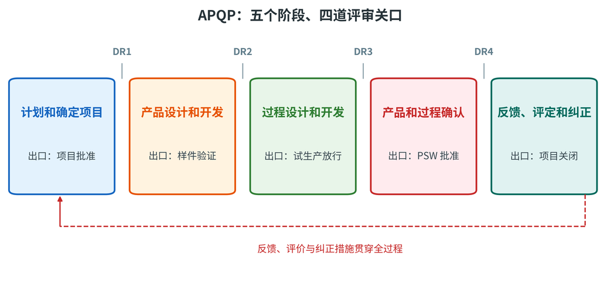

- **五阶段核心任务**：① 计划：把顾客声音翻译成设计目标；② 设计：出图纸与 DFMEA（设计失效模式与后果分析）；③ 过程：出 PFMEA（过程失效模式与后果分析）与试生产控制计划；④ 确认：做试生产、MSA 与 PPAP；⑤ 反馈：减变差并把教训回流。
- **各阶段交付物**：阶段 1 交设计目标、初始 BOM（物料清单）与流程图；阶段 2 交 DFMEA、DVP&R（设计验证计划与报告）与样件控制计划；阶段 3 交流程图、PFMEA 与试生产控制计划；阶段 4 交 MSA、初始能力研究与 PPAP；阶段 5 交经验教训。
- **四道关口**：项目批准、样件验证、试生产放行、PSW（零件提交保证书）批准；交付物齐、风险关闭、资源到位才过门，结论只有通过／有条件通过／不通过。

**记住：每个阶段用交付物证明“做完了”，每道关口用评审决定“能不能进下一阶段”。**

## 项目策划：团队与时间计划

- **组织小组**：指派过程负责人（项目经理），组建跨职能小组：工程、制造、材料控制、采购、质量、人力资源、销售、现场服务、供方与顾客
- **确定范围**：定角色职责、识别内外部顾客、用 QFD 定义顾客要求、评估所需专业与可行性
- **三项约束**：成本、进度与限制条件在项目启动时说清，并明确需要顾客提供哪些帮助
- **时间计划**：任务、分工、事件与起止日期，记录实际进展；用关键路径法识别关键路径
- **并行与沟通**：同步工程替代串行交接；与顾客、供方团队定期沟通，培训把要求传到每个执行者

## 阶段一：计划和确定项目

- **顾客声音三来源**：市场调研（访谈、问卷、市场测试）、历史保修与质量信息、团队经验
- **其他输入**：业务计划／营销策略、产品与过程标杆、产品与过程设想、可靠性研究、顾客输入
- **输出（交阶段二）**：设计目标、可靠性和质量目标、初始材料清单、初始过程流程图
- **其余输出**：特殊产品与过程特性的初始清单、产品保证计划、管理者支持（进度、资源与产能）
- **怎么写目标**：设计目标是顾客声音的可测量翻译；可靠性目标如”不允许安全失效”，质量目标用 ppm、问题数、废品率

## 阶段二：产品设计与开发（含验证与确认）

- **设计输出（交阶段三）**：DFMEA、DFM／DFA、设计验证、设计评审、样件控制计划、图纸与规范、材料规范、更改
- **APQP 输出**：新设备／工装／设施要求、特殊特性、量具与试验设备要求、可行性承诺与管理支持
- **DFMEA**：评估失效概率与后果，是特殊特性的最初来源；活文件，顾客需求变化就要更新

| 维度 | 设计验证（Verification） | 设计确认（Validation） |
| --- | --- | --- |
| 回答的问题 | 做得对不对：输出满足规定要求吗 | 用得对不对：产品满足预期用途吗 |
| 依据 | 设计输入与规范 | 顾客需求与使用条件 |
| 时机 | 设计输出阶段，样件之前或同时 | 验证成功之后，通常在最终产品上 |
| 典型证据 | 设计评审、替代计算、试验与演示 | 样件与试生产试验、实际工况验证 |

- 一句话：验证防”图纸错”，确认防”产品不合用”；DVP&R 跟踪验证进度

## 阶段三：过程设计与开发（含试生产准备）

- **输入**：DFMEA、图纸与规范、特殊特性、工装与检具要求、小组可行性承诺
- **输出（交阶段四）**：包装标准、过程流程图、场地平面布置、特性矩阵、PFMEA、试生产控制计划（含防错）、过程指导书、MSA 与初始能力研究计划
- **PFMEA 的边界**：假定产品设计满足要求、来件材料正确；不靠改设计解决过程薄弱环节，设计缺陷的后果归 DFMEA
- **PFMEA 四个下游**：确认过程特殊特性、编控制计划、编作业与检验指导书、改进过程设计
- **试生产准备四件**：工装验收（尺寸、节拍、能力、防错）、检具先做 MSA、人员资格、物料与场地的追溯标识

## 阶段四：产品与过程确认

- **试生产（significant production run）**：必须使用生产工装、生产设备、生产环境（含生产操作者）、生产设施、生产量具与生产节拍
- **试生产产品的用途**：初始过程能力研究、MSA、节拍验证、过程审核、生产确认试验、PPAP、包装评价、质量策划认定
- **MSA 与初始能力**：对控制计划列出的测量系统做 GR&R；初始研究至少 25 组、每组 4 件（不少于 100 件）
- **判据的前提**：先用 MSA 确认量得准，再谈过程能力；量具不可信，能力指数就没有意义

| $P_{pk}$ | 判读 | 行动 |
| --- | --- | --- |
| $>1.67$ | 满足要求 | 维持并持续改进 |
| $1.33\sim1.67$ | 目前可接受 | 制定改进计划，提高能力 |
| $<1.33$ | 不满足要求 | 与顾客联系，100% 检验、修订控制计划 |

- **PPAP**：证明已正确理解顾客要求，且过程在报价节拍下有能力稳定生产

## 阶段五：反馈、评定与纠正

- **不是”项目结束”**：量产后反馈把问题送回设计与工艺，形成闭环
- **四项输出**：减少变差、提高顾客满意、改进交付与服务、有效使用经验教训与最佳实践
- **减少变差**：控制图区分特殊原因与普通原因；消除特殊原因靠纠正，减少普通原因靠改进
- 顾客满意是评价策划有效性的最终考场；减少普通原因也可能同时降成本
- **经验教训来源**：TGR／TGW、保修与性能数据、纠正措施计划、相似产品、DFMEA／PFMEA 研究；最佳实践库让一次项目变成下一个项目的输入

## 案例：一个零件从概念到量产的时间轴

- 以铝合金电池托盘为例：焊接与气密性是特殊特性；下列时间轴随顾客节点与产品复杂度变化

| 时间 | 阶段 | 关键动作 | 交付物与出口 |
| --- | --- | --- | --- |
| 0～1 月 | 策划 | 顾客声音、设计目标、团队与时间计划 | 项目批准 |
| 1～3 月 | 产品设计 | DFMEA、图纸、DVP&R、样件试制 | 样件验证通过 |
| 3～5 月 | 过程设计 | 流程图、PFMEA、工装检具、试生产 CP | 试生产放行 |
| 5～6 月 | 确认 | 试生产、MSA、初始能力、PPAP | PSW 批准 |
| 6～7 月 | 投产 | 爬坡、生产 CP、首件与节拍验证 | 量产 |
| 7～12 月 | 反馈 | 减少变差、顾客满意、经验教训 | 项目关闭 |

- 时间是示例：关键路径决定项目长短，顾客节点与变更会改写整条时间轴

## 关键特性与特殊特性

- **CTQ**：从顾客声音分解出的关键质量特性，必须可测量、可判定，否则只是口号
- **特殊特性**：顾客指定（含法规与安全）和／或组织根据产品与过程知识选定的产品特性与过程参数
- **判定口径**：可能影响安全性、法规符合性、可装配性、功能、性能或后续生产过程（ISO/TS 16949 第 7.2.1.1 条）
- **标识与来源**：来源＝顾客要求、PFMEA、过去问题、法规、相似零件；图纸、DFMEA／PFMEA、CP、作业指导书使用同一套符号
- **分类管理**：安全／法规类通常要求防错或 100% 检验并可追溯；功能类可抽检＋SPC；外观类靠目视标准；特殊特性必须全部列入控制计划

## 供应链质量策划：供方 APQP 与监控

| 层级 | 要求 | 证据 |
| --- | --- | --- |
| 顾客 → 组织 | 顾客特殊要求、提交等级、批准状态 | 顾客批准与 PSW |
| 组织 → 供方 | 供方按 APQP 阶段提交进度与交付物 | 供方 APQP 跟踪表 |
| 供方 → 分供方 | 材料与工艺变更必须申报并重新批准 | 供方 PPAP 与变更通知 |
| 传递特性 | 供方过程形成、组织不再加工或验证即使用的特性 | 双方控制计划中的对应行 |

- **同一套要求向下传**：组织应期待供方具有与顾客要求相同的绩效；新供方、新工艺、安全与法规特性件采用更严跟踪
- **监控三视图**：时间（里程碑是否延期）、风险（红黄绿）、证据（交付物是否齐）；月度例会＋阶段门评审＋现场走访
- **早期预警与升级**：连续两次延期、关键特性 Cpk＜1.33、PPAP 临时批准、变更未申报 → 升级到采购与管理层，必要时驻厂
- **判据**：不是”供应商说在做”，而是有证据、有日期、有责任人

## 控制计划 CP：三份文件、三个切换点

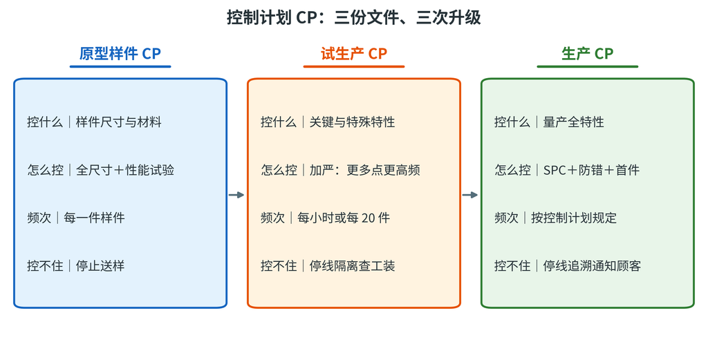

- **是什么**：同一套列结构的三份 CP；切换点就是样件、试生产、投产三个节点
- **为什么**：试生产阶段工装、人员、节拍都不稳，只能靠加严（更高频次、更多检查点）兜住
- **怎么判断**：四列必须齐——控什么、怎么控、多频繁、控不住怎么办；版本与现场不一致即失效

## 控制计划的列结构

| 区块 | 包含的列（示例） | 填写要点 |
| --- | --- | --- |
| 表头（第 1～14 列） | CP 编号、零件号与更改等级、组织／工厂、核心小组、联系人、日期、顾客批准 | 版本与批准可追溯 |
| 过程定位（第 15～17 列） | 零件／过程编号、过程名称与操作描述、机器／装置／工装 | 与过程流程图编号一一对应 |
| 特性（第 18～21 列） | 编号、产品特性、过程特性、特殊特性分类 | 特殊特性必须全部列入 |
| 方法（第 22～25 列） | 规格／公差、评价与测量技术、样本容量与频率、控制方法 | 测量技术须先通过 MSA |
| 反应计划（第 26 列） | 超差与失控时的隔离、标识、处置与责任人 | 写到”谁在多久内做什么” |

- 26 列的顺序就是一条逻辑链：特性 → 规格 → 测量 → 频次 → 控制方法 → 反应
- **责任**：跨职能小组编制、质量与顾客批准、工艺维护，变更即升版
- 列空着不是”没问题”，而是”没人负责”

## CP 三要素：控什么、怎么控、控不住怎么办

- **控什么**：产品特性（图纸与规范上的尺寸、材料、性能）＋过程特性（与产品特性有因果关系的输入变量，如电流、压力、时间、扭矩）
- **怎么控**：控制方法（SPC、检验、通止规、防错、抽样）＋测量技术＋样本容量与频率；方法强度由风险等级决定
- **控不住怎么办**：反应计划——停线、隔离可疑品与不合格品、标识、处置责任人、记录、通知、复检
- 反应计划要写给**离过程最近的人**：操作者、调整工、班组长，并明确其权限
- 质量人员必须有**停止生产的权力**（ISO/TS 16949 第 5.5.1.1 条）

| 要素 | 关键问题 | 常见错误 |
| --- | --- | --- |
| 控什么 | 这个特性是否影响安全、功能或法规？ | 只列产品特性，漏掉过程特性 |
| 怎么控 | 用什么方法、多频次、谁执行？ | 频次拍脑袋，不与 FMEA 风险挂钩 |
| 控不住怎么办 | 谁在多久内做什么？ | 只写“通知质量部”，没有隔离与处置 |

## CP 与 FMEA 的关系：每一列从哪来

| FMEA 栏目 | 在 CP 中的落点 | 迁移规则 | 一个例子 |
| --- | --- | --- | --- |
| 失效模式与原因 | 过程特性（第 20 列） | 把原因变成可监控的参数 | 电流不足 → 焊接电流 |
| 严重度与分类 | 特殊特性分类（第 21 列） | 决定控制强度 | 严重度高 → 安全特性 |
| 预防措施 | 控制方法（第 25 列） | 防止原因发生 | 防错夹具替代人工确认 |
| 探测措施 | 评价技术与样本频次（第 23、24 列） | 发现并拦截不良 | 每班拉伸试验 3 件 |

- **制表规则**：PFMEA 的一行原因，写成 CP 的一行控制——特性、规格、测量、频次、控制方法、反应计划依次填
- **怎么判断**：CP 每一行都应能追到 PFMEA 的一个失效模式或原因；追不到，就是拍脑袋控制
- **分工**：FMEA 回答“可能怎么坏、后果多严重、为什么坏”；CP 回答“现场怎么防、怎么查、出了怎么办”

## CP 编制实例：焊接工序

- 以铝合金电池托盘框架的 MIG 焊为例，表中的数值仅用于课堂演练，不代表任何具体产品规范

| 工序与特性 | 规格／公差 | 测量技术与频次 | 控制方法与反应计划 |
| --- | --- | --- | --- |
| 焊接电流 | $180\pm10$ A | 焊机数显，首件＋每 2 h 记录 | 超限自动报警，停线调整并隔离 |
| 焊接时间 | $0.8\pm0.1$ s | 焊机数显，同电流 | 超限报警，调整后首件确认 |
| 保护气流量 | $15\pm2$ L/min | 流量计，每班首件 | 低于下限停线，检查气路 |
| 焊缝熔深 | $\ge 2.0$ mm | 金相剖切，每班 1 件 | 不合格加倍抽检并追溯当班 |
| 接头拉剪力 | $\ge 3.5$ kN | 拉伸试验，每班 3 件 | 不合格停线，隔离当班产品 |
| 焊缝气密性 | 泄漏率 $\le 5$ mL/min | 气密检测，100% | 超限隔离并追溯当班 |

- 每一行都应能追到 PFMEA 的一条失效原因；追不到，就说明这一行是“拍脑袋”

## 变更管理与文件联动：ECN→FMEA→CP

| 环节 | 要做的事 | 证据 |
| --- | --- | --- |
| 授权 | 由授权人批准，ECN 编号，写明变更内容与生效日期 | 工程更改文件 |
| 影响分析 | 评估成本、进度、库存、已发运产品、工装检具、文件与培训 | 影响分析记录 |
| 文件联动 | 图纸与规范 → DFMEA → PFMEA → CP → 作业指导书 → 检具 | 各文件新版本 |
| 现场切换 | 变更点首件确认、断点标识、旧件与旧文件隔离、培训 | 首件报告与培训记录 |

- **三条路径**：S 变看安全与验证，O 变看预防与能力，D 变看探测与样本
- 触发：设计、材料、供方、场地、工艺、节拍变更，以及客诉与现场失效；“无影响”也要签字
- **重新提交**：设计记录、规范或材料更改引起产品改变时，必须重新提交 PPAP 批准
- **底线**：变更单无”FMEA 影响结论”栏、或 FMEA 版本落后图纸，不得放行

## APQP 与 CP 的四个常见误区

- 把 APQP 当“填表”：文件齐全，风险没识别，评审走过场
- FMEA 做完锁进抽屉：控制计划、作业指导书没有同步更新
- 控制计划由质量部门单独编写：设计、工艺不参与，特性选错
- 只在量产前做一次：设计变更、工艺调整后不更新，CP 失效

> 工具的产出不是文件，而是被现场执行的控制动作。

## GJB 是什么：从 ISO 9001 到 GJB 9001C

> GJB 是“国家军用标准”：合同里一引用，它就是必须执行的强制条款。

| 标准 | 名称 | 管什么 |
| --- | --- | --- |
| GJB 9001C-2017 | 质量管理体系要求 | 军工版 ISO 9001，军工单位建体系的依据 |
| GJB 3206A-2010 | 技术状态管理 | 三条基线（功能／分配／产品）与更改控制 |
| GJB 6117-2007 | 装备环境工程术语（含产品层次定义） | 零件、部件、组件、设备、分系统、系统的划分 |
| GJB 6387-2008 | 专用规范编写规定 | 系统规范、研制规范、产品规范怎么写 |
| GJB 190A | 特性分类 | 关键特性、重要特性与关键件、重要件 |
| GJB 438C | 军用软件开发文档通用要求 | 软件配置项的文档链 |

- 相对民品体系的三条加严：**技术状态管理**（改了什么、谁批的）、**关键件与六性**（可靠性与安全性要定量）、**定型程序**（设计定型、生产定型）
- 民用靠市场准入（3C、体系认证），军用靠合同＋定点＋军检——**合同是军标的开关**
- 判据：拿到一个军品项目，先问“合同引用了哪几份标准”

## 装备研制程序与三类规范：军工版 APQP

> 民品讲 APQP 五阶段，军品讲研制程序与三条基线——同一件事的两种说法。

| 阶段 | 主要工作 | 出口（基线／文件） |
| --- | --- | --- |
| 论证 | 立项论证、战术技术指标 | 研制总要求（功能基线：系统规范） |
| 方案 | 方案设计、关键技术攻关 | 方案评审（分配基线：研制规范） |
| 工程研制 | 初样、正样、联调与试验 | 设计定型试验 |
| 设计定型 | 性能与使用性考核 | 设计定型（产品基线：产品规范） |
| 生产定型 | 工艺定型、批产条件 | 生产定型、批产 |

- 三类规范（GJB 6387）各对一条基线：系统规范管“整机要什么”、研制规范管“分到设备多少”、产品规范管“交付检验什么”
- 规范正文六章式：范围、引用文件、要求、验证、包装运输贮存、说明事项——要求章逐条写指标，验证章逐条写怎么验
- 与 APQP 对照：五阶段≈APQP 五阶段；阶段评审≈关口评审；研制规范≈技术条件＋控制计划；基线冻结≈版次受控
- 判据：能不能说清“这一版冻的是哪条基线、要改谁来批”

## 产品层次：GJB 6117 的六层与判据三问

> 分层的唯一标准是“能不能单独试验、交付”，不是“零件大小”。

| 层级 | 定义要点 | 判据 |
| --- | --- | --- |
| 零件 | 不经装配制成的最小单元 | 无装配工序 |
| 部件 | 两个及以上零件装配，功能不完整 | 有装配、需再装才起作用 |
| 组件 | 有相对独立功能的组成部分 | 功能相对完整，随设备考核 |
| 设备 | 独立功能，能单独试验与交付 | 能单独试验、验收、交付 |
| 分系统 | 系统中完成某一方面功能 | 分系统级试验 |
| 系统 | 完成规定任务功能的整机 | 系统级试验与验收 |

- 三问判据：**有无装配？功能是否相对完整？能否单独试验交付？**
- 允许跳级：某多路吸收光谱层析测量系统只分 系统 → 设备 → 组件（跳过分系统）；软件按配置项挂系统级
- 案例规模：1 套系统 ＝ 6 台设备 ＋ 1 个软件配置项 ＋ 保障设备，组件 30 类
- 判据：产品树是后面所有文件的骨架——规范、BOM、FMEA、复验都挂在某一级上

## 关键件与放行：军品凭什么交付

> 军品验收不是“东西看起来好”，而是“证据一件不缺”。

| 环节 | 做什么 | 依据／产出 |
| --- | --- | --- |
| 特性分类 | 定关键特性、重要特性，判出关键件／重要件 | GJB 190A；案例 30 类组件判出 8 处 |
| 风险分析 | FMECA ＝ FMEA ＋ 危害性分析 CA | GJB/Z 1391；比民品 FMEA 多一层危害性 |
| 首件鉴定 | 首件全尺寸、全性能检验，确认工艺稳定 | 首件检验记录 |
| 外购件复验 | 合格供方＋到货复验＋随机文件五件套 | 合格证、说明书、检验报告、装箱单、开箱验收单 |
| 放行 | 验收证据包（18 项，与 PPAP 18 项对齐）齐套后签字 | 相当于民品的 PPAP 提交 |

- 关键件／重要件的判据是“特性”：含关键特性的产品＝关键件，只含重要特性的＝重要件
- 军品多一层技术状态：改一个件要同步改图纸、规范、BOM、FMEA、复验清单，且要有人批
- 判据：随机文件五件套缺一件，验收就过不去——这是最容易被忽略的失分点

## 民军对照：八对等同结构与三点差异

> 民标与军标不是两套逻辑，是同一逻辑的两种表述——工具可以互相借用。

| 民品工具（本讲） | 军标口径 | 共同本质 |
| --- | --- | --- |
| APQP 五阶段与交付物 | 研制阶段＋三条基线＋研制规范 | 策划先行 |
| DFMEA／PFMEA | FMECA＝FMEA＋危害性分析 CA（GJB/Z 1391） | 风险预防与排序 |
| 特殊特性 | 关键件／重要件（GJB 190A） | 抓少数必须重点控制的对象 |
| DVP&R 设计验证 | 研制规范“验证”章＋验证矩阵 | 验证与确认 |
| MSA／GR&R | 标定与测量不确定度 | 数据可信才谈能力 |
| SPC／Cpk | 试验过程控制与判据 | 过程受控再谈能力 |
| PPAP 18 项证据 | 验收证据包 18 项 | 放行要证据 |
| 8D 八步 | 问题归零与闭环 | 根因→纠正→预防再发 |

- 三点差异：**驱动源**（顾客声音 vs 合同指标与基线）、**目标**（量产稳定 vs 研制＋验收）、**风险面**（技术状态、环境适应性、可靠性、保密）
- 借用方向：民标工具补军标的“过程控制、证据包、问题闭环”三块空白；军标补民标的“技术状态与六性”
- 判据：先问“这套标准服务的是批量一致性，还是研制验收”

## 中国质量奖：三个可复制的质量模式

> 上一页把 8D 对到军标的“问题归零”；这一页看国家层面嘉奖的是什么——不是某项技术，而是可复制的管理模式。
- **是什么**：国家质量领域最高荣誉，分组织与个人两类；首届三家为航天科技、海尔与刘源张院士
- **航天科技**：“基于质量问题**双归零**的系统管理方法”——把每次质量问题的处理变成十条可检查的判据
- **海尔**：以“人单合一双赢”为核心的质量管理模式——用户需求与员工核算直接挂钩，人人对市场结果负责
- **刘源张（中国工程院院士）**：在我国推广、普及全面质量管理做出突出贡献——个人奖颁给“把方法教给一个行业”的人
- **三种模式的分工**：航天防问题重复，海尔让责任到人，刘源张让方法长在组织里
- **与认证的分界**：认证是准入底线（符合标准才有证书），质量奖是绩效标杆（结果领先且方法可复制）

**结论：质量竞争分三层——符合标准、过程稳定、模式卓越；质量奖评的是第三层，也是本讲工具链要服务的那一层。**

## 航天双归零：技术五条与管理五条

> 上一页说航天科技靠“双归零”拿到质量奖；这一页把判据拆开：同一个问题要闭两次环。
- **技术归零五条**：定位准确、机理清楚、问题复现、措施有效、举一反三——回答“故障是什么、凭什么不再发生”
- **管理归零五条**：过程清楚、责任明确、措施落实、严肃处理、完善规章——回答“为什么会漏、制度怎么补”
- **两个环都要闭合**：只做技术归零，同类问题换个零件还会再来；顺序先技术后管理
- **与 8D 的对应**：D1～D3 定位与复现、D4～D6 机理与措施验证、D7 举一反三、D8 完善规章
- **判据**：五条逐条有证据——试验数据、复现记录、验证件、规章编号；缺一条就是归零不彻底

| 类型 | 五条判据 | 证据形态 |
| --- | --- | --- |
| 技术归零 | 定位准确、机理清楚、问题复现、措施有效、举一反三 | 试验数据、复现方案、验证件 |
| 管理归零 | 过程清楚、责任明确、措施落实、严肃处理、完善规章 | 过程记录、责任认定、规章修订 |

**结论：技术归零让“问题不重复”，管理归零让“同类漏洞不再出现”；两次验收缺一次都不算闭环。**

## 缩写速查：工具与军标

> 工具缩写记“谁先谁后”，军标缩写记“管哪一层”。

| 缩写 | 英文全称 | 中文 |
| --- | --- | --- |
| APQP | Advanced Product Quality Planning | 产品质量先期策划 |
| CP | Control Plan | 控制计划 |
| FMEA | Failure Mode and Effects Analysis | 失效模式与后果分析（DFMEA 设计／PFMEA 过程） |
| RPN | Risk Priority Number | 风险顺序数 |
| AP | Action Priority | 行动优先级 |
| MSA／GR&R | Measurement System Analysis／Gauge Repeatability and Reproducibility | 测量系统分析／量具重复性与再现性 |
| SPC | Statistical Process Control | 统计过程控制 |
| PPAP | Production Part Approval Process | 生产件批准程序 |
| Cpk | Process Capability Index | 过程能力指数 |

| 缩写 | 标准名称／全称 | 中文 |
| --- | --- | --- |
| GJB | Guojia Junyong Biaozhun | 国家军用标准 |
| GJB 9001C | 质量管理体系要求（军工版 9001） | 建体系 |
| GJB 6117 | 装备环境工程术语（含产品层次定义） | 分层 |
| GJB 6387 | 专用规范编写规定 | 写规范 |
| GJB 3206A | 技术状态管理 | 三条基线 |
| GJB 190A | 特性分类 | 关键件／重要件 |
| GJB/Z 1391 | 故障模式、影响及危害性分析指南（FMECA） | 风险分析 |
| GJB 438C | 军用软件开发文档通用要求 | 软件配置项 |
| CI | Configuration Item | 技术状态项（配置项） |

- 工具缩写按链记：**APQP → FMEA → CP → MSA → SPC → PPAP**；军标缩写按四层记：体系 → 程序 → 对象 → 文件
- FMECA 比 FMEA 多一个 CA（Criticality Analysis，危害性分析）——军标口径多称 FMECA（含 CA），FMEA 仍是其主体

## 内容块 1 小结：五大工具与 APQP

- **一条主线**：顾客声音 → 设计目标 → 设计输出 → 过程设计 → 试生产验证 → 量产反馈
- **三份核心文件**：FMEA 管风险、CP 管控制、PPAP 管证据
- **四道关口**：项目批准、样件、试生产、投产；最常被问的是样件验证（阶段二出口）与 PSW 批准（阶段四出口）
- **一句话**：APQP 管“什么时候做什么”，CP 管“现场怎么控”，PPAP 管“凭什么放行”
- **标准落地**：ISO 9001 是通用及格线，GJB 9001C 是军工版；研制程序＋三类规范＝军品的“APQP＋规范体系”，验收证据包＝军品的 PPAP

## 推导留给 AI：五大工具总览与 APQP

- APQP 五阶段的交付物中，哪些必须在 PPAP 之前完成？哪些可以并行？让 AI 排一条关键路径。
- 如果顾客要求跳过 DFMEA 直接做 PFMEA，会漏掉哪一类风险？举一个具体零件说明。
- 控制计划的“反应计划”应包含哪几类动作？让 AI 对照 IATF 16949 条款核对。
- 用一句话向车间班组长解释：为什么 MSA 是 SPC 的前提？

# 第二部分 · FMEA、MSA 与 PPAP

- FMEA 是在失效发生之前预见后果
- DFMEA 与 PFMEA：对象、时机与输出
- S／O／D 评分、RPN 与 AP 行动优先级
- MSA 的重复性再现性；PPAP 的 18 项证据
- **承上**：上一部分讲完五大工具的框架、APQP 与控制计划；本部分要回答“会怎么坏、数据可不可信、凭什么放行”。

## FMEA 是什么：事前的、系统的、可量化的

> 上一页把内容块 2 的三件事摆开；这一页回答 FMEA 具体防什么、怎样才算做完。
- **是什么**：FMEA（失效模式与后果分析）在设计或工艺冻结之前，把潜在失效模式、后果与起因摆上桌，并给出预防与探测措施。
- **为什么**：失效一旦流到现场，代价就从“改图纸”变成“召回与赔偿”；FMEA 的作用就是把代价前移。
- **三个特征**：事前——在图纸或工艺冻结前进场；系统——跨职能小组一起做；可量化——用 S／O／D 打分（$S$ 严重度、$O$ 频度、$D$ 探测度，均为 1～10 无量纲，后文逐项给准则）。
- **怎么判断**：一次 FMEA 是否有效，看它有没有在冻结前改变设计；图纸一个字没改，这次 FMEA 就只是存档记录。
- **两个部分**：FMA（失效模式分析）回答“会怎么坏”，FEA（失效后果分析）回答“坏了有多严重”。

**记住：FMEA 的价值在冻结前改变设计，不在会后交一份表。**

## FMEA 的三种类型与 DFMEA／PFMEA 的区别

| 维度 | DFMEA（设计） | PFMEA（过程） | 判断口诀 |
| --- | --- | --- | --- |
| 分析起点 | 设计输入：功能、要求、顾客与法规 | 过程流程图：工序、工步、人机料法环 | 从要求出发／从流程出发 |
| 后果看向 | 最终用户、整车、法规 | 本工序、下游工序、最终用户 | 谁承受这个后果 |
| 控制手段 | 设计验证、样件试验、公差与材料分析 | 防错、SPC、首件与巡检 | 试验验证／现场控制 |
| 交给对方 | 设计特殊特性、设计失效影响 | 过程特殊特性、控制计划输入 | 特性往哪里流 |
| 责任主体 | 设计工程师牵头 | 工艺与制造工程师牵头 | 谁签字谁负责 |

- **三类**：SFMEA 管接口、DFMEA 管物、PFMEA 管做；接口风险最容易在三者之间漏掉
- **DFMEA 行文示例**：功能”提供不小于 3.5 kN 的连接强度” → 失效”焊点缺失” → 影响 S＝9 → 起因 O＝5（电极磨损） → 现行控制 D＝8 → 措施：焊点计数与漏打报警
- **PFMEA 前提**：来件与材料正确、产品基本设计正确；设计没给防错结构归 DFMEA，给了没执行归 PFMEA

## 结构分析：从系统到要素

- FMEA 七步法里，结构分析排在功能与失效之前：没有结构，功能就挂不上
- 结构分析回答两问：分析对象的边界在哪、它由哪些层级构成
- DFMEA 的结构：系统 → 子系统 → 组件（零件），逐层编号
- PFMEA 的结构：过程项 → 过程步骤（工序）→ 工作要素（人机料法环）
- 每个元素写清：名称编号、层级、与相邻元素的接口
- 边界要显式声明：哪些零件、工序不在本次范围
- 结构树必须与过程流程图一致，流程图漏一道工序就漏一段风险

> 常见错误：把失效起因塞进结构层——“电极磨损”是起因，不是结构元素。

## 功能分析与失效链

- 功能的写法：动词＋名词＋可测量的要求，如“提供不小于 3.5 kN 的连接强度”
- 功能写不清，失效模式就写不出来
- 失效＝功能未满足：功能丧失、功能退化、功能间歇
- 系统级还要看功能过强与非预期功能
- 失效链：起因 → 模式 → 影响，自下而上传递
- 下一层的失效影响就是上一层的失效模式，层级错则 S 失真
- 点焊：电极磨损 → 焊点缺失或虚焊 → 接头强度不足、碰撞脱开
- 影响定 **S**，起因定 **O**，现行控制定 **D**

> 功能分析做不细，失效模式就会写成“尺寸不良”这类结果，而不是“怎么坏”。

## 严重度 S 的评分准则

| S | 判定准则 | 典型例子 |
| --- | --- | --- |
| 10 | 无任何预警地危及人身安全或违反法规 | 制动失效、安全带固定点断裂 |
| 9 | 有预警地危及人身安全或违反法规 | 报警后转向助力丧失 |
| 7～8 | 主要功能丧失或严重降级，产品不可用 | 发动机无法启动、密封失效漏油 |
| 5～6 | 次要功能丧失或降级，顾客可察觉并抱怨 | 车窗升降变慢、异响 |
| 3～4 | 外观或舒适性缺陷，多数顾客能察觉 | 饰板划伤、间隙不均 |
| 1～2 | 几乎无影响，只有极少数顾客或专家能察觉 | 内部不可见面的轻微色差 |

- S 只能靠设计更改降低，过程控制、检验与培训都降不了 S。
- 安全与法规相关的失效，S 取 9 或 10，不按发生概率打折。

**记住：S 只看后果——安全件不能因为“从没出过事”就打成 5 分。**

## 频度 O 的评分准则

- O 评价**失效起因**发生的可能性，1 最低、10 最高；要有数据，不能凭印象

| O | 发生率（每千件） | 折合 ppm | 判断依据 |
| --- | --- | --- | --- |
| 10 | ≥100 | ≥100 000 | 无预防控制，或同类问题反复发生 |
| 8～9 | 20～50 | 20 000～50 000 | 预防控制弱，历史数据支持高发 |
| 6～7 | 2～10 | 2 000～10 000 | 有预防控制但执行不稳定 |
| 4～5 | 0.1～0.5 | 100～500 | 预防控制有效，偶发漂移 |
| 1～3 | ≤0.01 | ≤10 | 防错或设计上消除，长期无发生记录 |

- 取证三条路：本过程历史数据、同类产品数据、过程能力研究
- O 与 S 独立：安全件的 O 再低，S 仍是 9 或 10
- 降 O 靠预防：防错、参数收紧、来料与工装一致性

## 探测度 D 的评分准则

- D 评价**现有控制能否在失效流出之前发现它**，1 最容易、10 最难

| D | 探测能力 | 典型控制方式 |
| --- | --- | --- |
| 9～10 | 几乎探测不到，或只能靠顾客投诉发现 | 无控制、仅靠用户反馈 |
| 7～8 | 人工目视或抽检，漏检率高 | 下线目视、每班破坏抽检 |
| 5～6 | 人工量具 100% 检测，依赖人的执行 | 卡尺全检、扭矩扳手复核 |
| 3～4 | 自动检测并能报警、停线或隔离 | 在线视觉、传感器监控、自动分选 |
| 1～2 | 防错使缺陷不可能发生或不可能流出 | 定位销防错、扫码校验、结构防呆 |

- D 与 S 无关：只回答“发现得了吗”，不回答“有多严重”
- 先用防错，再用自动检测，最后才是加人加抽检
- 只降 D 不降 O：问题还在发生，只是被发现得早一点

## RPN 的计算、阈值与风险矩阵

公式

$$\mathrm{RPN}=S\times O\times D,\qquad 1\le S,O,D\le 10,\qquad \mathrm{RPN}\in[1,\,1000]$$

- 算例：漏焊 $S=9$、$O=5$、$D=8$，则 $\mathrm{RPN}=360$；阈值由企业在 FMEA 程序里自定，常见口径是 $S\ge7$ 或 $\mathrm{RPN}\ge100$ 优先处置
- 三个缺陷：乘积掩盖 S 差异、不同组合同分、降 D 就能把分数做低；新版 FMEA 改用 AP 决策，RPN 退为参考指标与趋势跟踪
- S×O 风险矩阵是 RPN 的可视化：深色格优先，但安全项（$S\ge9$）即使 RPN 小也必须优先，用 AP 定性
- 记住一句：RPN 用来排序，不用来决定”要不要管安全”

## 行动优先级 AP

- AP（Action Priority）由 AIAG 与 VDA 联合手册引入：按 S、O、D 的**区间组合**查表，得 H／M／L
- 分组：S 分 9～10、7～8、4～6、2～3、1；O 分 6～10、4～5、2～3、1；D 分 7～10、5～6、2～4、1
- 判读顺序固定：**先 S、再 O、最后 D**；S 高时 D 再好也压不到 L

| AP | 含义 | 必须做什么 |
| --- | --- | --- |
| H | 高优先级 | 必须采取措施，或书面说明不措施的理由并经管理层批准 |
| M | 中优先级 | 宜采取措施；不措施需说明理由并留存 |
| L | 低优先级 | 可接受，无需额外措施，保留记录 |

- 算例：漏焊 $S=9,O=5,D=8$ → H；错件 $S=6,O=8,D=7$ → M，尽管 RPN 336 与 360 只差 24
- AP 不是乘积，不会因探测手段好把安全风险平均掉
- 判为 H 的行必须有措施、责任人、完成日期与验证证据

## 建议措施、跟踪闭环与 FMEA 评审会

- **措施三条路径**：降 S（只能改设计）、降 O（预防）、降 D（探测）；只降 D 不降 O，问题还在发生
- 措施写清四件事：做什么、谁负责、何时完成、用什么证据验证；措施后重评 S／O／D，填”措施结果”三列
- **文件闭环**：PFMEA 改 → 控制计划改 → 指导书与培训改 → 稽核
- **评审会**：会前发结构树与证据包（每行有出处、无出处标”待证”）；会中按失效链逐行挑战（后果、证据、能否发现）；会后措施入册并跟踪
- **判据**：会后至少一条设计、工艺或控制变更；无变更须书面”维持现状”理由

## FMEA 案例：焊接漏焊

- **场景**（教学案例）：车身总成点焊 OP-30，每台 128 个焊点，节拍 60 s
- **失效模式**：焊点缺失（漏焊）、虚焊（未熔透）
- **失效影响**：接头强度不足，碰撞时脱开，危及乘员 → $S=9$
- **失效起因**：电极磨损、参数漂移、搭接间隙超差、程序跳步 → $O=5$（约每 2 000 件 1 次）
- **预防控制**：电极修磨周期管理、焊接电流与通电时间监控
- **探测控制**：下线目视＋每班破坏抽检 3 件，漏焊目视几乎不可见 → $D=8$
- **结果**：$\mathrm{RPN}=360$，AP 为 H，必须立即整改

> 关键判断：S=9 一票定优先级，不能因为“历史上没出过事”把 O 压低。

## FMEA 案例：装配错件

- **场景**（教学案例）：支架装配 OP-50，左右支架外形相似、同料架相邻摆放
- **失效模式**：左右件混装（错件）
- **失效影响**：装配干涉、间隙超差，顾客可察觉并抱怨，需返修 → $S=6$
- **失效起因**：零件无防错特征、料架未分区、新员工培训不足 → $O=8$（约每 50 件 1 次）
- **现行控制**：作业指导书图示（预防很弱）、下线终检目视 → $D=7$
- **结果**：$\mathrm{RPN}=336$，AP 为 M
- **对比漏焊**：RPN 只低 24，AP 却差一档——S=6 与 S=9 不是同一量级

> 两个案例并排看：RPN 接近时，先做哪个由 S 决定，这就是 AP 存在的理由。

## FMEA 的七个常见错误与评分争议裁决

- **七个错误**：当填表任务、失效模式写成结果、起因只写”操作者失误”、把 S 当概率、用加检验代替解决起因、小组只有质量部门、一次做完锁进抽屉
- **争议来源**：S 是价值判断，O 缺数据，D 凭感觉；裁决顺序是先统一评分表版本，再统一”后果边界”，最后才打分
- **S 与 O**：S 按最终后果定、安全与法规取 9～10，不打折；O 必须有历史、同类或过程能力证据，无数据时取保守档并标”待证”
- **D**：看现有控制的探测能力与逃逸路径，不看”有没有检查”这个动作
- **程序与判据**：记录两种意见、证据与裁决理由，由跨职能小组定、不投票、不取平均；同一失效跨项目评分差超过 2 档必须复核并更新锚例库

## FMEA 与 CP、SPC 的接口：输出接到哪里

- PFMEA 的 AP＝H 行，CP 必须加密抽样并写清反应计划；CP 的控制方法超出 PFMEA 写明的范围，说明控制没有依据
- CP 写“SPC 控制图”，就要同时交监控对象、子组与判异准则——三者不齐，图就是装饰
- CP 的测量技术必须先过 MSA：测量系统不合格，数据不能用于放行
- 追溯链：FMEA 行号 → CP 行号 → 控制图编号 → 反应计划；变更闭环：FMEA 改版 → CP 改版 → 指导书与培训 → 稽核

> FMEA 是“想到的”，CP 是“写下的”，作业指导书是“做到的”，三者版本必须对齐。

## MSA：测量系统也是一个过程

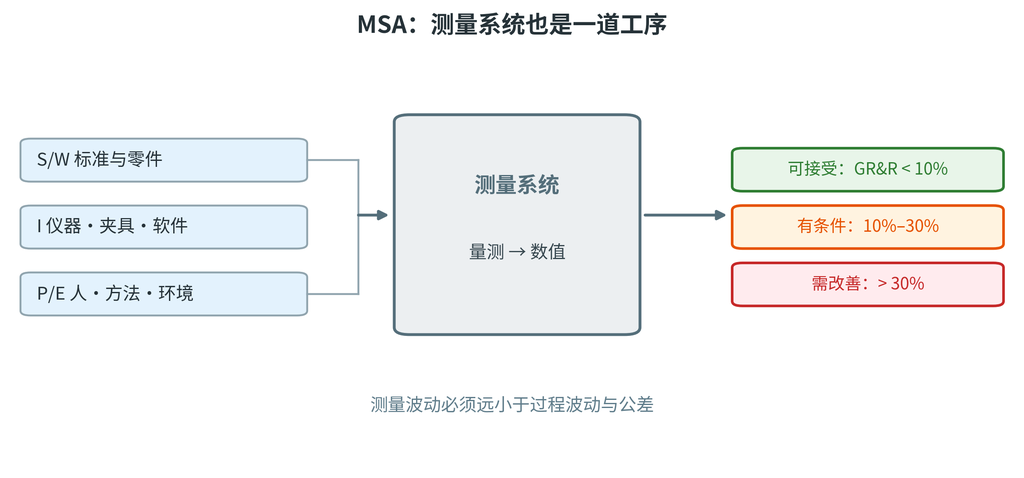

- **是什么／为什么**：把测量当成一道工序——五类输入进、一个数值出；测量波动会混进数据，GR&R 超过 30% 时 SPC 与 Cpk 只能作参考
- **怎么判断**：GR&R＜10% 可接受，10%—30% 有条件接受，＞30% 先修测量系统，再谈过程
- **三个必做时机**：新量具投用前、修理校准后、PPAP 提交前；顺序 MSA 合格 → 过程受控 → Cpk 达标 → 才谈放行

## 测量系统误差的六个来源

- 测量误差不是“量具不准”四个字，按人、机、料、法、环、标准六路去找

| 来源 | 典型表现 | 对策 |
| --- | --- | --- |
| 人 | 读数习惯不同、夹持力不一致、知道在做试验 | 统一作业指导书、盲测、培训与考核 |
| 机 | 分辨力不足、刚性差、磨损、夹具定位不稳 | 提高分辨力、修磨、换夹具、定期校准 |
| 料 | 零件自身圆度、锥度、批次差被当成测量误差 | 固定测量位置、增加零件数、分层分析 |
| 法 | 基准不一致、测量点不同、软件滤波参数不同 | 统一基准与测量规范、锁定软件参数 |
| 环 | 温度、湿度、振动、照明变化 | 恒温、隔振、固定照明、记录环境 |
| 标准 | 校准链断裂、基准值不确定度大 | 建校准链、用更高一级设备定基准值 |

- **五类误差**（MSA 手册口径）：位置变差——偏倚、线性、稳定性；宽度变差——重复性、再现性
- 分辨力准则：量具分辨力应不大于公差或过程变差的 1/10
- 经验：重复性大查设备与夹具，再现性大查人与方法

## 例题：GR&R 均值极差法 —— 题干与思路

> 练什么：用 3 人 × 5 件 × 3 次的测量数据算出 EV、AV、GRR、PV、TV，并判断波动主要来自设备还是人。

| 零件 | A 均值／极差 | B 均值／极差 | C 均值／极差 |
| --- | --- | --- | --- |
| 1 | 10.001／0.006 | 10.009／0.006 | 9.995／0.006 |
| 2 | 10.021／0.006 | 10.029／0.006 | 10.014／0.004 |
| 3 | 9.979／0.006 | 9.988／0.004 | 9.972／0.004 |
| 4 | 10.041／0.006 | 10.049／0.006 | 10.034／0.004 |
| 5 | 9.960／0.004 | 9.968／0.004 | 9.952／0.004 |

- **已知**：轴径规格 $10.00\pm0.05$ mm，公差 $T=0.10$ mm；每格为该评价人对该零件 3 次重复的均值／极差（mm）；系数 $K_1=0.5908$（3 次）、$K_2=0.5231$（3 人）、$K_3=0.4030$（5 件）。
- **求**：①$\bar R$ 与 $EV$（mm，保留 4 位）；②$R_{\bar X}$ 与 $AV$；③$GRR$、$PV$、$TV$ 与 %GRR（总变差、公差两种分母）。
- **路线**：①三行极差求 $\bar R$ 与 $EV$ → ②三列均值求 $R_{\bar X}$ 与 $AV$ → ③合成 $GRR$ → ④求 $PV$、$TV$ 与 %GRR。

## 例题：GR&R 均值极差法 —— 分步解答

**第 1 步 求 $\bar R$ 与 $EV$**：$\bar R_A=0.028/5=0.00560$、$\bar R_B=0.026/5=0.00520$、$\bar R_C=0.022/5=0.00440$，$\bar R=0.0152/3=0.00507$ mm；$EV=K_1\bar R=0.5908\times0.00507=0.00299$ mm（设备／重复性）。

**第 2 步 求 $R_{\bar X}$ 与 $AV$**：$\bar X_A=50.002/5=10.0004$、$\bar X_B=50.043/5=10.0086$、$\bar X_C=49.967/5=9.9934$ mm，$R_{\bar X}=10.0086-9.9934=0.0152$ mm；$AV=\sqrt{(0.5231\times0.0152)^2-0.00299^2/(5\times3)}=\sqrt{0.0000632-0.0000006}=0.00791$ mm（人／再现性）。

**第 3 步 合成 $GRR$**：$GRR=\sqrt{0.00299^2+0.00791^2}=\sqrt{0.0000715}=0.00846$ mm。

**第 4 步 求 $PV$、$TV$**：零件均值 10.0017、10.0213、9.9797、10.0413、9.9600 mm，$R_p=0.0813$ mm；$PV=0.4030\times0.0813=0.0328$ mm，$TV=\sqrt{0.00846^2+0.0328^2}=0.0339$ mm。

**第 5 步 求占比与 $ndc$**：$EV/TV=8.8\%$、$AV/TV=23.4\%$、$GRR/TV=25.0\%$、$GRR/T=8.5\%$；$ndc=1.41\times PV/GRR=1.41\times0.0328/0.00846=5.5\to5$。

**判读**：按总变差 $25.0\%$ 属有条件接受（10%～30%），按公差 $8.5\%$ 则可接受；$AV$ 远大于 $EV$，改进方向在人——培训、刻度与辅助夹具。

**易错点/验算**：$AV$ 必须减去 $EV^2/(nr)$，不减会高估人的贡献；%GRR 要写清分母是 $TV$ 还是公差 $T$。

## GR&R 判读：10% 与 30% 准则

- 上例：$\bar R=0.00507$ mm、$EV=0.00299$ mm、$AV=0.00791$ mm、$GRR=0.00846$ mm
- $R_{\bar X}=0.0152$ mm、$R_p=0.0813$ mm、$PV=0.0328$ mm、$TV=0.0339$ mm
- 占比：EV 8.8%、AV 23.4%、GRR／TV 25.0%、GRR／公差 8.5%，$ndc=5$
- 判读：按总变差 25.0% 属**有条件接受**；按公差 8.5% 则可接受
- 原因：再现性远大于重复性，问题在人——培训、刻度、辅助夹具

| %GRR | 判读 | 处置 |
| --- | --- | --- |
| <10% | 可接受 | 保持，按周期复核 |
| 10%～30% | 有条件接受 | 视重要性、量具成本与维修费用决定，需改善 |
| >30% | 不可接受 | 必须改进；已测库存品需复检并追溯 |

- 常见错误：只报百分比、不说分母，两种口径可能落在不同档

## GR&R 三种方法怎么选

- **三种方法**：极差法、均值极差法（X̄–R）、方差分析（ANOVA）
- 极差法：2 人×5 件，快而粗，只能给总 GR&R，分不开设备与人的贡献
- 均值极差法：3 人×10 件×2～3 次，能分 EV 与 AV，AIAG 常用，手算可行
- ANOVA：同样本，能分零件、评价人、交互作用，还能给置信区间
- 选择判据：现场筛查用极差法，常规验收用均值极差法，高价值或低 GR&R 用 ANOVA
- 共同前提：零件覆盖过程变差，评价人随机化、盲测，不按固定顺序测量
- **判据**：交互作用显著时，均值极差法会高估或低估 GR&R，应改用 ANOVA

| 方法 | 样本 | 能分离 | 适用 |
| --- | --- | --- | --- |
| 极差法 | 2 人×5 件 | 总 GRR | 快速筛查 |
| 均值极差法 | 3 人×10 件×2～3 次 | EV／AV | 常规验收 |
| ANOVA | 同上 | EV／AV／交互 | 高价值或低 GRR |

## 属性测量系统与 Kappa

- 计数型特性（合格／不合格、通／止）算不了 GR&R，改用属性一致性分析
- 三个指标：有效性、漏判率（不合格判成合格）、误判率（合格判成不合格）
- Kappa 扣除“碰巧一致”：$\kappa=\dfrac{P_o-P_e}{1-P_e}$

| A ＼ B | B 判合格 | B 判不合格 | 合计 |
| --- | --- | --- | --- |
| A 判合格 | 39 | 1 | 40 |
| A 判不合格 | 3 | 7 | 10 |
| 合计 | 42 | 8 | 50 |

- 算例：$P_o=46/50=0.92$，$P_e=(40\times42+10\times8)/50^2=0.704$，得 $\kappa=0.73$
- 判读：$\kappa>0.75$ 良好，$0.4\sim0.75$ 需改善，$<0.4$ 不可接受；本例属边缘
- 提醒：一致率 92% 看着好，但漏判率 $3/10=30\%$，三成不良品会流出

## 偏倚、线性与稳定性研究

公式

$$\mathrm{bias}_i=\bar x_i-x_{\mathrm{ref},i},\qquad \mathrm{linearity}=|\beta_1|\times \text{process variation}$$

- **偏倚**：观测均值减基准值，回答”整体偏了多少”；判据：偏倚的置信区间包含 0 才可判”无显著偏倚”
- **线性**：偏倚随被测尺寸变化的斜率，回答”从头到尾偏得一样吗”；判据：斜率不显著，或线性占过程变差／公差的比例在 5%／10% 两档以内
- **做法**：选覆盖量程的基准件，每件重复测 ≥10 次，做偏倚对基准值的回归；单点校准不能覆盖全量程
- **稳定性**：同一基准件、同一测量系统，偏倚随时间、环境与班次的变化；用 X̄–R 控制图同时盯均值与极差
- **判据与处置**：控制图判异、趋势、阶跃，或偏倚变化超过公差 5% 预警线→不稳定；缩短校准周期、恒温、固定夹具、锁定软件参数

## MSA 与 Cpk 联合判读案例

- **场景**（教学情景）：某轴径报告 Cpk＝1.38 申请放行，GR&R＝32%，ndc＝4
- **第一步先看 MSA**：32% 不可接受、ndc＜5，不能直接放行；看控制图：过程受控，但测量波动占方差约 10%，真实能力被低估
- **第二步修正**：按方差相减修正，Cpk 约 1.46；修正值不能替代量具改进
- **第三步改量具**：先改夹具与量具，复测 GR&R 降到 9%、Cpk＝1.46，才提交 PPAP
- **两个方向**：随机波动让 Cpk 被低估；偏倚进均值，可能偏高也可能偏低
- **判据**：GR&R＞10% 时 Cpk 报告必须附影响说明；＞30% 不得放行——MSA 不是 Cpk 的附件，而是准入证

修正公式

$$C_{pk}^{\mathrm{corr}}=\frac{\min(USL-\bar X,\ \bar X-LSL)}{3\sqrt{s_{\mathrm{obs}}^2-s_{\mathrm{ms}}^2}}$$

## PPAP 是什么：量产前的放行程序

- **是什么**：规定生产件与散装材料的批准要求；核心是证明”这条线、这套工艺，在量产节拍下能持续合格”
- **三个关键词**：理解要求、实际生产、持续能力——不是”文件齐”
- **三种状态**：完全批准、临时批准（限时限量）、拒收；触发情形：新零件、纠正、设计或材料更改
- **怎么判断**：$Ppk\ge1.67$、MSA 可接受、控制计划已落实，三条缺一不可
- **与 APQP**：PPAP 是阶段 4 的收口、也是对阶段 3 的总检验；18 项证据是各阶段交付物的汇总，前四阶段没产出就凑不齐；PPAP 未批准，APQP 不能关闭
- **提交等级**：由顾客定，不能自选；等级 1 与 5 不是”少干活”，只是证据放在哪里

## PPAP 的 18 项证据清单与证据包编审

| 设计类 1～3 | 风险类 4～6 | 验证类 7～11 | 交付类 12～18 |
| --- | --- | --- | --- |
| 1 设计记录 | 4 DFMEA | 7 尺寸结果 | 12 控制计划 |
| 2 工程更改文件 | 5 过程流程图 | 8 材料／性能试验 | 13 PSW |
| 3 顾客工程批准 | 6 PFMEA | 9 初始过程研究 | 14 AAR |
|  |  | 10 MSA 研究 | 15 散装材料检查表 |
|  |  | 11 实验室资格文件 | 16 生产件样品 |
|  |  |  | 17 标准样品 |
|  |  |  | 18 检查辅具 |

- 记忆法：按”设计—风险—验证—交付”四段记；⑨⑩（初始过程研究、MSA）不过，其余再齐也没用
- **编包**：一份索引＋18 项证据＋版本清单；证据链＝图纸特性 → PFMEA 行 → CP 行 → 尺寸／能力报告 → PSW
- **审包顺序**：先 PSW 与等级，再看 ⑨⑩，最后抽查 ④⑥⑫ 一致性；任一证据不能回溯到”量产节拍、量产工装、量产人员”，包就不成立

## PPAP：六步流程与五个等级

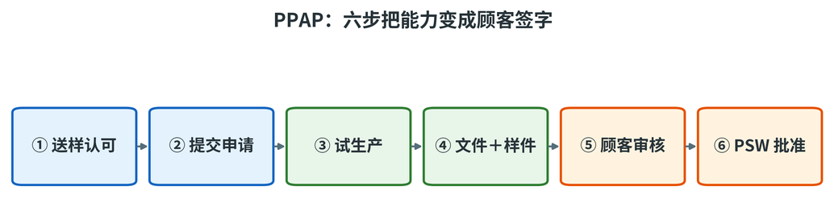

| 等级 | 向顾客提交的内容 | 适用场合 |
| --- | --- | --- |
| 1 | 只交 PSW（外观件加 AAR） | 散装材料、成熟件 |
| 2 | PSW＋样品＋部分支持数据 | 一般件 |
| 3 | PSW＋样品＋整套支持数据 | 常规等级，新件默认 |
| 4 | PSW＋顾客规定的其他要求 | 顾客有特殊规定 |
| 5 | 全套资料留供方现场 | 顾客到厂审核 |

- **六步**：送样认可→提交申请→试生产→文件＋样件→顾客审核→PSW 批准
- **判据**：能力＋MSA＋控制计划三条缺一不可；等级由顾客定，不能自选

## PPAP 案例：一次被退回的提交

- 背景（教学案例）：某压铸件按等级 3 首次提交，两周后被拒收
- 尺寸不全：图纸 12 个特性只测 9 个，缺 3 个关键特性
- 过程研究不达标：$Ppk=1.21<1.33$，特殊原因未消除就交数据
- 测量系统不可接受：$\%GRR=32\%>30\%$，量具分辨力不足
- 文件不一致：PFMEA 新增的防错没进控制计划，版本对不上
- PSW 失真：声明量产节拍生产，样件却来自手工试制线
- 处置：转临时批准，齐全尺寸、改量具、重做能力研究

> 根因不是文件不全，而是把 PPAP 当成文员工作：没人对“证据是否真实”负责。

## 量产爬坡与 PPAP 是什么关系

- **PPAP 批准**：证明“这条线、这套工艺能做出合格件”，是量产门票
- **爬坡**：证明“能稳定做出足够多的合格件”，考的是产能、节拍、良率与供应链
- 爬坡风险：节拍提升使工艺窗口变窄、新员工上岗、供应商产能不足、工装磨损
- 安全投产：按顾客要求实施早期生产遏制（如 GP-12），加严抽检与快速反应
- 爬坡前：完成 run-at-rate、产能验证、CP 更新与应急预案；爬坡中盯 PPM、FPY、停线
- PPAP 临时批准时：限时限量，爬坡计划必须与顾客共同批准
- **判据**：连续稳定生产、能力达标、无重大客诉，才可退出加严；不是“到期就退”
- 一句话：PPAP 是门票，爬坡是考试；门票不等于毕业

## 内容块 2 小结：FMEA、MSA 与 PPAP

- 三句话：FMEA 事前排序、MSA 证明数据可信、PPAP 用 18 项证据换放行
- 证据链：APQP → FMEA → CP → MSA → SPC → PPAP，断一环整条链都不成立；两条回路是 SPC 报警回写 FMEA、PPAP 拒收回写阶段 3
- 三种断点：FMEA 与 CP 不对应、CP 无 MSA 支撑、证据与现场不符
- 计算模板：写公式 → 代数据 → 出结果 → 判读 → 说原因与对策；失分点：S 当概率、GR&R 分母用错、把等级 1 当“不用准备”
- 接口题：给现场场景，问用哪个工具、前后是谁、输出交给谁

> 工具的价值不在文件，而在它改变了哪一个决定。

## 推导留给 AI：FMEA、MSA 与 PPAP

- 为什么 FMEA 的最新方法用 AP 取代 RPN 作为主要决策依据？让 AI 找出 $S=9$、RPN＝180 的反例并说明。
- 设计一个 GR&R 试验（几人、几件、几次），并说明如何算 EV、AV 与 GR&R 百分比。
- PPAP 的 18 项证据中，哪几项依赖 SPC 与 MSA 的输出？画出依赖关系。
- 若供应商 PPAP 被“临时批准”，量产前必须完成哪些补充验证？

# 第三部分 · SPC 与过程能力指数 Cp / Cpk

- 普通原因与特殊原因：两种波动，两种对策
- 控制图的构造与判异八准则
- Cp 与 Cpk：精度与准度的合成
- 一个完整的 Cpk 算例与判读
- **承上**：上一部分解决了风险排序、测量可信与放行证据；本部分要回答“过程稳不稳、能力够不够、Cpk 落在哪一档”。

## SPC 是什么：让过程可预测，并分清责任

> 上一页把内容块 3 的四个问题摆开；这一页回答 SPC 要解决什么、为什么能把责任分清。
- **是什么**：SPC（Statistical Process Control，统计过程控制）以控制图为主，分析过程及其输出，使过程保持受控并提高能力。
- **为什么**：受控才能预测；但受控不等于合格——合不合格还要看规格限（$USL$／$LSL$，上／下规格限，mm）。
- **怎么判断**：先看过程是否只受普通原因支配：异常来自局部就查现场，来自系统就改系统。
- 落地载体是控制计划（CP）：写清特性、样本量、频次与反应计划。
- 两种误判：把普通原因当特殊原因会越调越乱；把特殊原因当普通原因会让不良流出。

| 目的 | 回答的问题 | 现场动作 |
| --- | --- | --- |
| 稳定可预测 | 过程是否只受普通原因支配 | 维持参数，不随意调机 |
| 区分原因 | 异常来自局部还是系统 | 特殊原因查现场，普通原因改系统 |

**记住：SPC 的第一产出是“可预测”，第二产出是“责任分得清”——局部措施归现场，系统措施归管理层。**

## 波动的六个来源：5M1E

- 波动不可避免，先按 **5M1E** 把原因找全
- 普通原因多项叠加、始终存在；特殊原因突发、可查明

| 来源 | 典型普通原因 | 典型特殊原因 |
| --- | --- | --- |
| 人 | 技能差异、疲劳、操作习惯 | 新员工顶岗、违反作业标准 |
| 机 | 精度、磨损、夹具间隙 | 刀具崩刃、设备故障 |
| 料 | 成分波动、硬度均匀性 | 换批、混料、来料超差 |
| 法 | 参数、顺序、作业标准 | 参数误改、跳工序 |
| 环 | 温度、湿度、振动 | 季节变化、空调故障 |
| 测 | 量具分辨力、测量方法 | 量具未校准、读数错误 |

- 排查先确认“测”可信，再查人机料法环

## 控制图原理：3σ 与两类错误

- 三线：$CL=\mu$，$UCL/LCL=\mu\pm3\sigma$，$\sigma$ 由过程估计
- 第一类错误 $\alpha$：正常却判异，3σ 下 $\alpha=0.27\%$
- 第二类错误 $\beta$：已偏移却未报警，偏移越大 $\beta$ 越小

| 均值偏移 | 单点越界概率 | 平均报警点数 | 判读 |
| --- | --- | --- | --- |
| $0$ | $0.27\%$ | 370 点 | 正常误报水平 |
| $1\sigma$ | $2.28\%$ | 44 点 | 偏移小，检出慢 |
| $2\sigma$ | $15.9\%$ | 6.3 点 | 偏移中等 |
| $3\sigma$ | $50\%$ | 2 点 | 偏移大，很快报警 |

- 3σ 是误报与漏报的折中，不是数学最优
- 八准则并联使用，总误报率高于 $0.27\%$

## 控制图的构造：三条线与两把尺子

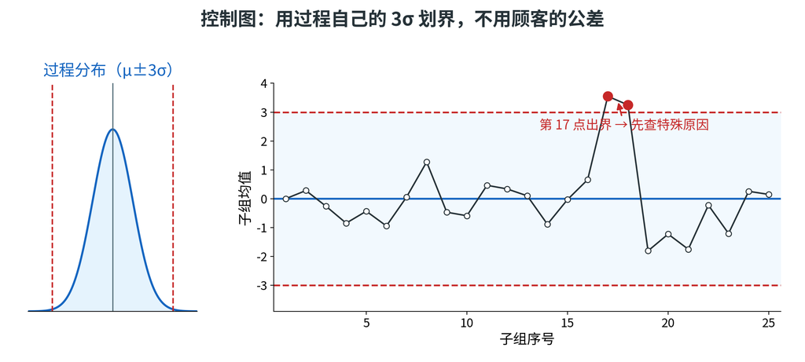

- **是什么**：CL＝过程均值，UCL／LCL＝CL±3σ；点与三条线的关系，就是判读的全部语言
- **为什么**：控制限取自过程自身的波动，回答”稳不稳”；规格限取自顾客要求，回答”合不合格”
- **怎么判断**：出界或非随机模式 → 查特殊原因；两把尺子不能互换——规格限当控制限会漏掉小偏移，控制限当规格限等于用现状替换顾客要求

## 控制图类型与选型

- 计量值信息多、检出强，能用计量值就不用计数值；子组容量定图型：$n=2\sim9$ 用 $R$，$n\ge10$ 用 $s$

| 数据 | 图 | 子组或单位 | 典型场景 |
| --- | --- | --- | --- |
| 计量值 | $\bar X$–$R$ | $n=2\sim9$ | 尺寸、重量，现场最常用 |
| 计量值 | $\bar X$–$s$ | $n\ge10$ | 大子组、自动采集 |
| 计量值 | $I$–$MR$ | $n=1$ | 单件、批次、破坏性检测 |
| 计数值 | $p$／$np$ | 样本量可变／固定 | 不良率、不良数 |
| 计数值 | $c$／$u$ | 单位固定／可变 | 缺陷数、单位缺陷数 |

- 计数图看两点：样本量是否固定、缺陷机会是否均一；一张图只监控一个特性
- **三步选型**：先问计量还是计数；再问子组能不能凑（$n=1$ 用 I–MR，$2\sim9$ 用 X̄–R，$\ge10$ 用 X̄–s）；最后问计数图分母固定吗（$p/np$，$c/u$）
- 常见错误：不同班次、不同模腔混成一个子组；用 p 图监控固定样本的不良数

## X̄–R 图的构造与子组抽样

- 组内同条件、组间有间隔；收 $k\ge20$ 组；中心线取各组均值与极差的平均

公式

$$UCL_{\bar X}=\bar{\bar X}\pm A_2\bar R$$

$$UCL_R=D_4\bar R,\qquad LCL_R=D_3\bar R$$

| $n$ | $A_2$ | $D_3$ | $D_4$ |
| --- | --- | --- | --- |
| 3 | 1.023 | 0 | 2.574 |
| 4 | 0.729 | 0 | 2.282 |
| 5 | 0.577 | 0 | 2.114 |
| 6 | 0.483 | 0 | 2.004 |
| 7 | 0.419 | 0.076 | 1.924 |

- 系数只由 $n$ 决定（$A_2=3/(d_2\sqrt n)$）；先看 $R$ 图——组内波动不稳，$\bar X$ 限也不可信
- 子组 $n=4\sim5$、组内只含普通原因（按时间／班次／模腔分层）；初始研究至少 25 组、100 件

## 判异八准则：八种图形信号

[figure not shown]

控制图判异八准则：A、B、C 区与八种异常模式

- 分区：C 区 ±1σ、B 区 1σ～2σ、A 区 2σ～3σ
- 准则 1：1 点出 A 区——查计算、量具与设备
- 准则 2、3：连续 3 点中 2 点落在 A 区或 A 区以外、连续 5 点中 4 点落在 B 区或 B 区以外——均值偏移
- 准则 4：连续 6 点递增或递减——刀具磨损、参数漂移
- 准则 5、7：8 点在两侧且 C 区无点、14 点交替——分层
- 准则 6、8：9 点同侧、15 点全在 C 区——均值变或数据失真

## 例题：X̄–R 控制图 —— 题干与思路

> 练什么：用 7 个连续子组的尺寸数据建 $\bar X$–$R$ 图，算控制限并判异；规格 $50.00\pm0.10$ mm，每组 5 件。

| 组 | 5 个测量值（mm） |
| --- | --- |
| 1 | 50.015 49.998 50.008 49.980 50.004 |
| 2 | 50.011 50.003 50.009 49.987 50.003 |
| 3 | 49.999 50.000 49.985 49.975 50.010 |
| 4 | 50.017 49.983 50.005 50.017 50.001 |
| 5 | 50.005 50.004 49.986 49.990 50.007 |
| 6 | 50.062 50.028 50.044 50.064 50.033 |
| 7 | 49.988 49.983 50.003 49.999 49.974 |

- **求**：①各子组均值 $\bar X_i$ 与总均值 $\bar{\bar X}$（mm，保留 4 位）；②各子组极差 $R_i$ 与极差均值 $\bar R$（mm）；③四条控制限并判异（$n=5$：$A_2=0.577$、$D_3=0$、$D_4=2.114$）。
- **路线**：①逐组算均值与极差 → ②求总均值与 $\bar R$ → ③代系数算四条控制限 → ④按判异准则读图、给处置。

## 例题：X̄–R 控制图 —— 分步解答

**第 1 步 求各子组均值**：$\bar X_1=250.005/5=50.0010$ mm，其余 $\bar X_2=50.0026$、$\bar X_3=49.9938$、$\bar X_4=50.0046$、$\bar X_5=49.9984$、$\bar X_6=50.0462$、$\bar X_7=49.9894$ mm。

**第 2 步 求总均值与各子组极差**：$\bar{\bar X}=350.036/7=50.00514$ mm；$R_i$（mm）＝0.035、0.024、0.035、0.034、0.021、0.036、0.029，$\bar R=0.214/7=0.030571$ mm。

**第 3 步 算控制限**：$\bar X$ 图 $UCL_{\bar X}=50.00514+0.577\times0.030571=50.00514+0.017639=50.02278\to50.0228$ mm，$LCL_{\bar X}=49.98750\to49.9875$ mm；$R$ 图 $UCL_R=2.114\times0.030571=0.06463\to0.0646$ mm，$LCL_R=0$。

**第 4 步 判异**：第 6 组 $\bar X_6=50.0462>UCL_{\bar X}=50.0228$，触发准则 1（1 点出 A 区）；$R$ 图最大极差 0.036＜$UCL_R=0.0646$，组内波动受控。

**判读**：先停线核数据，再按人机料法环查现场；第 6 组的 50.064 mm 仍在规格 50.10 以内——受控不等于合格，越控制限也不等于超规格，两把尺子不能混。

**易错点/验算**：$\bar R$ 是 7 个组极差的平均，不是最大极差（0.036）；先看 $R$ 图再看 $\bar X$ 图，组内波动不稳时均值限不可信。

## X̄–s 图：大子组与标准差

- 子组 $n\ge10$ 时用 $s$ 图，$n\le9$ 用 $R$ 图

公式

$$UCL_{\bar X}=\bar{\bar X}\pm A_3\bar s$$

$$UCL_s=B_4\bar s,\qquad LCL_s=B_3\bar s$$

| $n$ | $A_3$ | $B_3$ | $B_4$ |
| --- | --- | --- | --- |
| 5 | 1.427 | 0 | 2.089 |
| 10 | 0.975 | 0.284 | 1.716 |
| 15 | 0.789 | 0.428 | 1.572 |
| 20 | 0.680 | 0.510 | 1.490 |

- 每组标准差用 $n-1$ 分母，过程估计 $\hat\sigma=\bar s/c_4$
- $n\le9$ 时 $s$ 图与 $R$ 图效果接近，$R$ 图更易手算
- 判读仍先看 $s$ 图（组内波动），再看 $\bar X$ 图（组间位置）

## 计数型控制图：p、c 与 u 图

- $p$ 图监控不良率，样本量可变；$np$ 图样本量必须固定；$c$ 图监控固定检验单位内的缺陷数；$u$ 图统计单位缺陷数，检验单位可变

公式

$$\bar p=\frac{\sum d_i}{\sum n_i},\qquad UCL_p=\bar p+3\sqrt{\frac{\bar p(1-\bar p)}{n_i}},\qquad LCL_p=\max\left(0,\ \bar p-3\sqrt{\frac{\bar p(1-\bar p)}{n_i}}\right)$$

- 算例：$\bar p=3\%$、$n=200$ → $UCL_p=6.62\%$；$\bar c=4$ → $UCL_c=\bar c+3\sqrt{\bar c}=10$；$\bar u=0.8$ 个/m²、检 20 m² → $UCL_u=1.4$
- 正态近似要求 $n\bar p\ge5$ 且 $n(1-\bar p)\ge5$；$p$ 图限值随 $n$ 变化呈阶梯状，越界先核对样本量
- $c$／$u$ 图关键在折算：面积、台数不同不能直接比缺陷数；连续高点先分层（班次、喷房、来料）

## 判异之后：处置流程与 SPC 实施八步

| 阶段 | 关键动作 | 输出或判据 |
| --- | --- | --- |
| 停 | 隔离报警后生产的产品 | 追溯批次，防流出 |
| 核 | 核对数据、量具、测量系统 | 排除假报警 |
| 查 | 按 5M1E 查特殊原因 | 用时间线比对换班换料 |
| 消 | 消除原因并验证 | 连续 25 点无异常 |
| 固 | 更新控制计划与 FMEA | 标准化并培训 |

- 不查原因就调参数是过度调整，会把波动放大；不能及时消除时，按 PPAP 要求通知顾客并提交纠正措施
- **实施八步**：准备（①选特性 ②选图型 ③定抽样 ④验测量）→ 建图（⑤采数 ≥25 组 ⑥算限画图）→ 运行（⑦判异处置 ⑧标准化：更新 CP／FMEA／作业标准）
- 关键：控制限由过程数据算，过程变了要重算；常见失败是只画图不处置，或拿规格限当控制限

## 受控、有能力与过程能力的三个前提

| 状态 | 图形表现 | 对策 |
| --- | --- | --- |
| 受控且有能力 | 点随机、$C_{pk}\ge1.33$ | 保持并监控漂移 |
| 受控但无能力 | 稳定但分布宽于公差 | 改系统：设备、工艺、材料 |
| 不受控 | 有越限、链或趋势 | 先消除特殊原因，再算能力 |
| 不受控但 $C_p$ 高 | 组内波动小、均值漂移 | $C_p$ 是潜在值，不能放行 |

- 能力指数不是拿到数据就能算，先过三道关：受控（无判异）、测量（GR&R≤10%，10%～30% 条件接受）、分布（独立、近似正态，非正态需变换）
- 样本量：初始研究至少 25 组、每组 4 件，共 100 件；规格要明确：双侧还是单侧，USL、LSL 与目标值各是多少
- 不受控时算出的 Cpk 混入异常波动，没有预测意义；组内 σ 小、均值漂移时 Cp 高而 Cpk 低，别被 Cp 骗

## Cp：只量波动的「潜在能力」

> 上一页划出能力研究的边界；这一页回答只看波动能算出什么。

$$C_p=\frac{USL-LSL}{6\sigma}=\frac{T}{6\sigma}$$

其中 $USL$、$LSL$ 为上、下规格限（mm），$T=USL-LSL$ 为公差宽度（mm），$\sigma$ 为过程标准差（mm），$C_p$ 为潜在能力指数（无量纲）。

- **是什么**：控制图回答“稳不稳”，$C_p$ 回答“稳了之后公差够不够宽”——只看精度、不看位置。
- **为什么**：它假设均值已在规格中心，是“把中心调正后能达到的上限”；中心偏了多少，要用 $C_a$ 去罚。
- **怎么判断**：先过受控、测量、分布三道关再报 $C_p$；$\sigma$ 用组内估计 $\hat\sigma=\bar R/d_2$ 或 $\bar s/c_4$，不能用总体标准差。
- 常见错误：用总标准差代替组内标准差，把特殊原因算进能力；$\sigma$ 一换 $C_p$ 就变，报告要写明用的是哪套 $\sigma$。

| $\sigma$（mm） | $C_p$（$T=0.20$ mm） | 对应等级 |
| --- | --- | --- |
| 0.030 | 1.111 | B 级 |
| 0.025 | 1.333 | A 级门槛 |
| 0.020 | 1.667 | A+ 门槛 |
| 0.015 | 2.222 | 能力富余 |

**记住：$C_p$ 只回答“公差够不够宽”，不回答“中心偏不偏”。**

## 精度与准度：靶心图

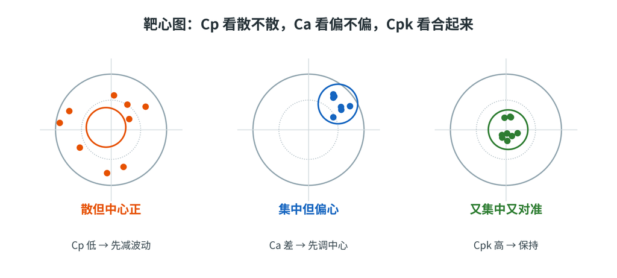

- **是什么**：把“散不散”（Cp）与“偏不偏”（Ca）拆成两件事，再看合起来的 Cpk
- **为什么**：偏心的代价常被低估——Cp＝2.0 的过程只要偏半个公差，Cpk 立刻掉到 1.0
- **怎么判断**：Cp 与 Cpk 差距大→先调中心；两者都低→先减波动

## 用 Ca 与 Cp 计算 Cpk

公式

$$C_a=\frac{|\bar X-C|}{T/2},\qquad C_{pk}=C_p\,(1-|C_a|)$$

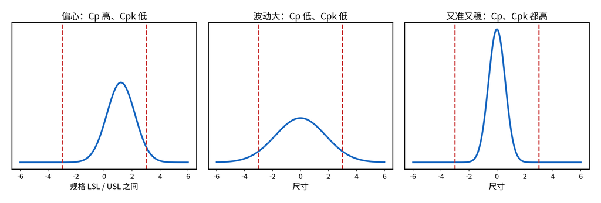

- $C_a$ 量的是均值与规格中心的偏差：Ca 越大，Cpk 被扣得越多
- 算例：$T=0.20$、$\sigma=0.020$、$\mu=50.03$ → $C_p=1.667$、$C_a=30\%$、$C_{pk}=1.167$——问题在偏心而不在波动
- 单边规格没有中心 $C$，$C_a$ 不适用，改看 $C_{pu}$／$C_{pl}$；恒有 $C_{pk}\le C_p$，只报 $C_p$ 等于隐瞒偏心

## 例题：10 个数据到 Cpk —— 题干与思路

> 练什么：把 10 个原始读数一步步算到 $C_{pk}$，并判断下一步先调中心还是先减波动。

| 已知 | 数值 |
| --- | --- |
| 规格 | $50.00\pm0.10$ mm，即 USL＝50.10 mm、LSL＝49.90 mm，公差宽度 $T=0.20$ mm |
| 数据（$n=10$） | 49.97、50.02、49.99、50.04、50.01、49.98、50.03、50.00、50.02、50.04（mm） |
| 判读门槛 | 五级：B 级 1.00～1.33、A 级 1.33～1.67，1.33 为量产及格线 |

- **求**：①$\bar X$ 与 $s$（mm，保留 4 位）；②$C_p$、$C_a$、$C_{pk}$（保留 3 位）；③按实际偏移折算的 ppm 与下一步动作。
- **公式**：$s=\sqrt{\sum d_i^2/(n-1)}$、$C_p=T/(6s)$、$C_a=|\bar X-C|/(T/2)$、$C_{pk}=C_p(1-|C_a|)$；其中 $d_i=x_i-\bar X$ 为偏差（mm），$x_i$ 为第 $i$ 个读数（mm），$n=10$ 为样本量，$T$ 为公差宽度（mm），$C$ 为规格中心（mm），$C_p$／$C_a$／$C_{pk}$ 为潜在能力指数／偏移比／过程能力指数（无量纲）。
- **路线**：①求和、求均值 → ②算各偏差与偏差平方和 → ③由平方和求 $s$ → ④算 $C_p$、$C_a$、$C_{pk}$ 与 ppm。

## 例题：10 个数据到 Cpk —— 分步解答

**第 1 步 求 $\sum x_i$ 与均值**：$\sum x_i=500.10$ mm，$\bar X=500.10/10=50.010$ mm。

**第 2 步 求偏差、平方和与 $s$**：$d_i$（mm）＝−0.040、+0.010、−0.020、+0.030、0、−0.030、+0.020、−0.010、+0.010、+0.030；$d_i^2$（mm²）＝0.0016、0.0001、0.0004、0.0009、0、0.0009、0.0004、0.0001、0.0001、0.0009，$\sum d_i^2=0.0054$；$s^2=0.0054/(10-1)=0.000600$，$s=\sqrt{0.000600}=0.0245$ mm。

**第 3 步 求 $C_p$ 与 $C_a$**：$C_p=0.20/(6\times0.0245)=0.20/0.1470=1.361$；$C_a=|50.010-50.000|/0.10=0.010/0.10=10.0\%$。

**第 4 步 求 $C_{pk}$ 与 ppm**：$C_{pk}=1.361\times(1-0.10)=1.225$；$Z_U=(50.10-50.010)/0.0245=3.67$、$Z_L=(50.010-49.90)/0.0245=4.49$，$p=\Phi(-3.67)+\Phi(-4.49)=0.000120+0.0000036\approx123$ ppm；按中心重合折算 $2\Phi(-3C_{pk})\approx239$ ppm。

**判读**：$C_{pk}=1.225$ 属 B 级（1.00～1.33），需改进；$C_p=1.361$ 已过 1.33，差距全在偏心——先把中心调回 50.000，$C_{pk}$ 可回到 1.361，成本远低于减波动。

**易错点/验算**：$s$ 的分母是 $10-1=9$；239 ppm 是按 Cpk 查表的中心重合值，123 ppm 才是按实际偏移两侧分别算出，两个口径不能混用。

## Cpk 五级判读：从 A+ 到 D

> 上一页给出 $C_a$ 与 $C_p$ 合成 $C_{pk}$ 的公式；这一页回答怎样按门槛分级处置。
- 判读前先确认两件事：过程受控、测量系统合格。

| 等级 | Cpk | 处理原则 | 常见误判 |
| --- | --- | --- | --- |
| A+ | ≥1.67 | 无缺点，考虑降低成本 | 规格过宽却当能力强 |
| A | 1.33≤Cpk<1.67 | 状态良好，维持现状 | 误写成“改进为 A 级” |
| B | 1.00≤Cpk<1.33 | 改进为 A 级 | 判为合格直接放行 |
| C | 0.67≤Cpk<1.00 | 不良较多，必须提升能力 | 只调中心不减波动 |
| D | <0.67 | 能力太差，重新设计或整改 | 用全检代替整改 |

- $C_{pk}$（过程能力指数，无量纲）：1.33 是量产及格线，1.67 是关键特性线。
- $C_{pk}=1.45$ 落在 A 级（$1.33\le C_{pk}\lt1.67$），处理原则是“维持现状”。
- A+ 也不要盲目降成本：先确认规格是否过宽、测量是否可信。

**记住：先定位区间、再选处置；等级只回答“落在哪一档”，不回答“为什么”。**

## Cpk 与 ppm：换算与前提

| Cpk | 双侧 ppm | 合格率 |
| --- | --- | --- |
| 0.67 | 44 431 | 95.56% |
| 1.00 | 2 700 | 99.73% |
| 1.33 | 66.1 | 99.9934% |
| 1.45 | 13.6 | 99.9986% |
| 1.67 | 0.54 | 99.99995% |
| 2.00 | 0.002 | ≈100% |

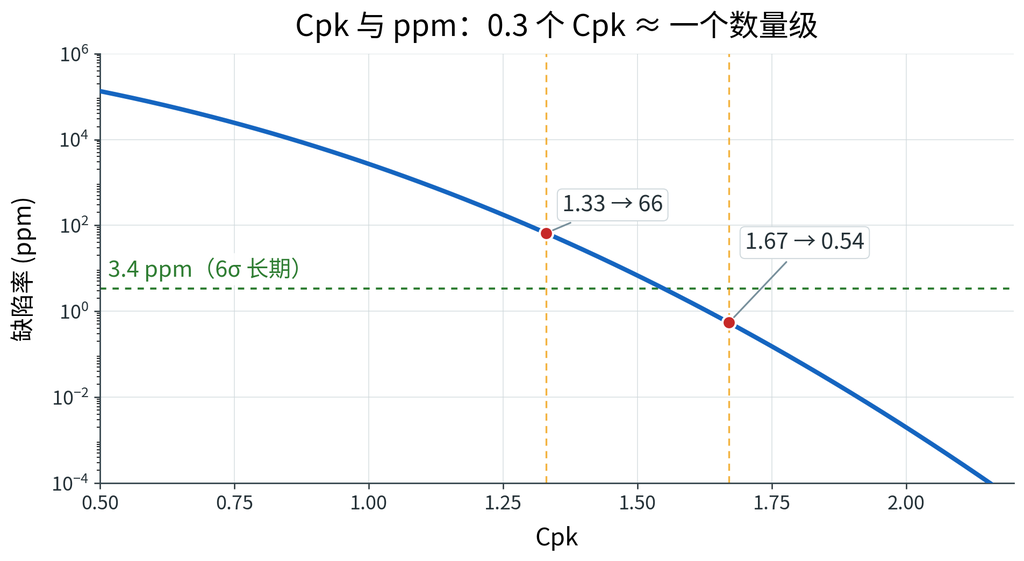

- 换算前提：正态、受控、均值与规格中心重合
- 实际偏移时两侧分别算 $p=\Phi(-Z_U)+\Phi(-Z_L)$
- 每提高约 0.3 个 Cpk，缺陷率约降一个数量级

## 理论推导：Cpk 与缺陷率

- 一般式：$p=\Phi(-Z_U)+\Phi(-Z_L)$，其中 $Z_U=(USL-\mu)/\sigma$、$Z_L=(\mu-LSL)/\sigma$
- 对称时（$\mu$ 在规格中心）$Z_U=Z_L=3C_{pk}$，于是 $p=2\Phi(-3C_{pk})$
- 代入一次：$C_{pk}=1.45$ → $Z=4.35$ → $p=2\Phi(-4.35)\approx13.6$ ppm，即双侧各 6.8 ppm
- 量级：$Z=3.00$ 对应 2700 ppm，$Z=6.00$ 对应 0.002 ppm——每提高约 0.3 个 $C_{pk}$，缺陷率降约一个数量级
- 前提：上式按“均值与规格中心重合”折算；实际偏移时两侧尾巴一大一小，必须分别算（完整算例表值 239 ppm、实际 123 ppm）

## Cpk 与 6σ：1.5σ 偏移

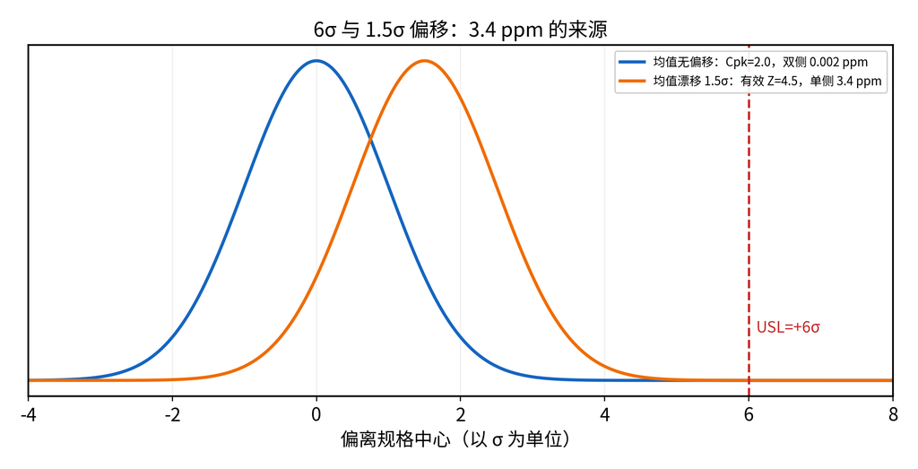

6σ 与 1.5σ 偏移：3.4 ppm 的来源

- 6σ 能力：$C_p=2.0$，规格限距中心 6σ
- 长期均值漂移 1.5σ，有效距离缩到 4.5σ
- 单侧尾部 $\Phi(-4.5)=3.4$ ppm，这就是 3.4 的来源
- 不漂移时双侧只有 0.002 ppm，两者差三个数量级
- “6σ＝3.4 ppm”是工程口径，不是 $C_{pk}=2$ 的直接结果
- 报告写清短期 Cpk 或长期 Ppk；偏移方向决定哪侧先失效

## Pp/Ppk：长期性能

- $P_p$、$P_{pk}$ 用全部数据的总体标准差，反映实际性能：$P_p=T/(6\sigma_{total})$，$P_{pk}=\min(USL-\mu,\ \mu-LSL)/(3\sigma_{total})$
- 同一过程恒有 $P_{pk}\le C_{pk}$，差距大说明漂移或异常多

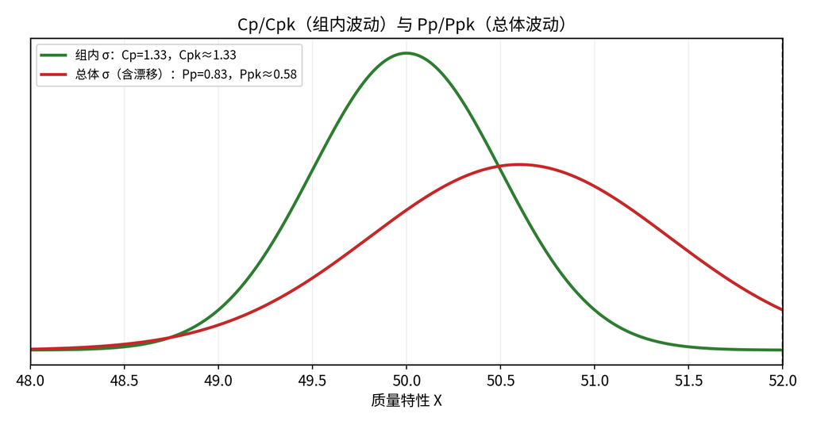

Cp/Cpk 用组内波动，PP/Ppk 用总体波动

| 口径 | 指数 | 回答的问题 |
| --- | --- | --- |
| 组内 σ | Cp/Cpk | 过程潜在能力 |
| 总体 σ | Pp/Ppk | 长期实际性能 |

- 图中组内 $C_p=1.33$，总体 $P_p=0.83$、$P_{pk}=0.58$；PPAP 初始研究：$P_{pk}>1.67$ 满足，1.33～1.67 条件接受，$<1.33$ 不满足

## 非正态与单侧规格

- 先看分布：直方图、概率图、正态性检验；双峰先分层，分层后往往各自正态

| 现象 | 先做什么 | 再算什么 |
| --- | --- | --- |
| 双峰 | 按设备、班次、料批分层 | 分层后分别算能力 |
| 偏态 | Box–Cox 或对数变换 | 变换后算 Cp／Cpk |
| 厚尾或未知 | 拟合分布或经验分位数 | 直接算 ppm |

- 偏态数据不变换就算 Cpk，尾部概率会被严重误算；也可拟合对数正态、Weibull，用分布函数算 ppm
- **单侧规格**：只有上限（如杂质 ≤0.5 ppm）用 $C_{pu}=(USL-\mu)/(3\sigma)$；只有下限（如强度 ≥45 HRC）用 $C_{pl}=(\mu-LSL)/(3\sigma)$；单侧无中心，$C_a$ 与双边 $C_p$ 都不适用，门槛同双侧
- 报告时注明：用了什么变换、什么分布、哪套 σ；接受准则与顾客共同确定

## Cpk 提升路径：先中心后波动

- 诊断：$C_{pk}=C_p(1-C_a)$，先看差距出在偏心还是波动
- $C_p$ 与 $C_{pk}$ 差距大 → 偏心为主，先调中心
- 调中心：刀具补偿、夹具定位、参数修正、来料匹配
- 减波动：设备精度、DOE 优化、来料一致性、防错
- 算例：$C_p=1.50$、$C_a=20\%$ → $C_{pk}=1.20$
- 中心调回后 $C_{pk}$ 可达 1.50，成本远低于换设备
- 若 $C_p$ 本身低于 1.33，调中心也只能到 $C_p$，必须先减波动

## 案例：Cpk 改善前后对比

**轴径 50.00±0.10 mm，现状 $\mu=50.03$、$\sigma=0.0259$：$C_p=1.287$，$C_{pk}=0.90$**

| 阶段 | $\mu$（mm） | $\sigma$（mm） | $C_{pk}$ |
| --- | --- | --- | --- |
| 现状 | 50.030 | 0.0259 | 0.90 |
| 调中心 | 50.000 | 0.0259 | 1.287 |
| 减波动 | 50.000 | 0.0250 | 1.333 |
| 再减波动 | 50.000 | 0.0200 | 1.667 |

- 第一步只移动 0.03 mm，$C_{pk}$ 从 0.90 升到 1.287；第二步 σ 降至 0.0250（−3.5%）达 1.33；再降至 0.0200 达 1.67
- 若只减波动不调中心，σ 要降到 0.0175（降 32%）；另一组同类案例（25.00±0.05）：1.01 → 1.33（调中心）→ 1.67（减波动）
- **对比前提**：同规格、同测量系统、同抽样口径；三段数据各配控制图，Cpk 提升必须来自 μ 回中或 σ 下降，只靠筛数据不算
- 常见错误：只报改善后一个点；不报样本量与测量系统；把 Ppk 当 Cpk

## 控制图与能力联合判读案例

- **场景**（教学情景）：同一工序三个特性 A、B、C，控制图与 Cpk 给出不同信号
- A：图受控、Cpk＝1.45——可放行，但仍要查 MSA 与规格是否过宽
- B：图受控、Cpk＝0.92——普通原因导致能力不足，改系统，不罚操作者
- C：图失控、Cpk＝1.60——高 Cpk 是假象，先消除特殊原因再谈能力
- **联合判读顺序**：MSA → 控制图 → Cpk → Ppk → 放行
- **判据**：控制图有任一判异，Cpk 只能作参考；Ppk 与 Cpk 差距大，查漂移与异常
- 一句话：控制图回答“稳不稳”，Cpk 回答“够不够”，两个答案不能互相代替

| 特性 | 控制图 | Cpk | 结论 |
| --- | --- | --- | --- |
| A | 受控 | 1.45 | 可放行，查 MSA |
| B | 受控 | 0.92 | 能力不足，改系统 |
| C | 失控 | 1.60 | 假能力，先消特殊原因 |

## CUSUM 与 EWMA 简介

- **为什么**：Shewhart 图对 1σ 左右的小偏移不敏感，CUSUM 与 EWMA 累积历史信息
- **CUSUM**：累积偏差，$C_i^+$ 向上、$C_i^-$ 向下；$k$ 常取 0.5σ，$h$ 常取 4～5σ
- **EWMA**：加权平均，$z_i=\lambda x_i+(1-\lambda)z_{i-1}$；λ 常取 0.05～0.3，L 约 3
- **判据**：CUSUM 的 $C^+$ 或 $C^-$ 超过 $h$ 报警；EWMA 的 $z_i$ 越限或连续同侧
- 参数权衡：λ 越小越灵敏于小偏移但滞后越大；h 越小越灵敏但误报越多
- 一句话：Shewhart 抓“大跳”，CUSUM 与 EWMA 抓“小漂”

$$C_i^+=\max(0,\ C_{i-1}^++x_i-\mu_0-k),\qquad C_i^-=\max(0,\ C_{i-1}^-+\mu_0-k-x_i)$$

$$UCL/LCL=\mu_0\pm L\sigma\sqrt{\frac{\lambda}{2-\lambda}}$$

## SPC 失败案例复盘

- **背景**（教学案例）：某线控制图挂了两年，客诉仍发生；审核发现五处断点
- 断点一：用规格限代替控制限——图永远“受控”，异常被藏起来
- 断点二：子组混班次、混模腔——组内波动被放大，控制限过宽
- 断点三：报警没有反应计划——操作员不知道停线、隔离、找谁
- 断点四：数据事后补录、剔除——图是“做给审核看的”
- 断点五：MSA 未做——量具分辨力不足，波动被抹平
- **复盘方法**：沿“取数—画图—判异—处置—标准化”五段查证据，不查口号
- **判据**：连续 3 个月报警处置记录、CP 更新记录、培训记录，三样缺一即失败

## Cpk 与 Ppk 报告模板

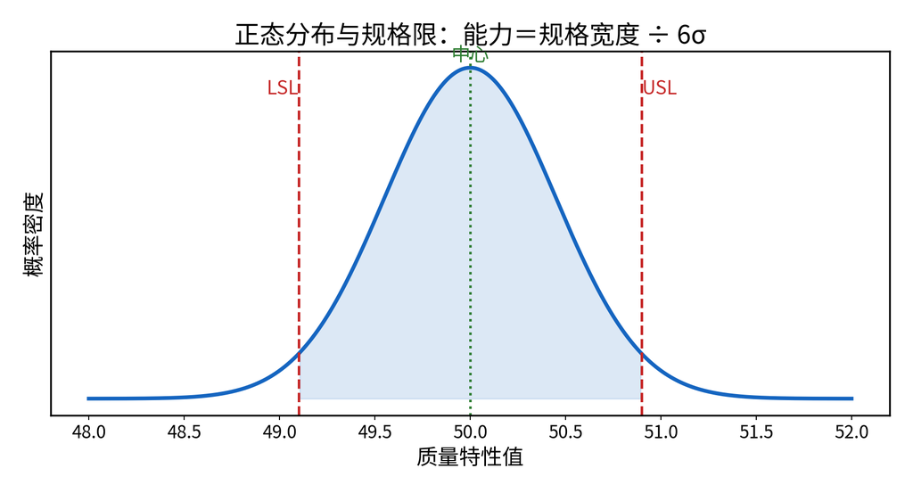

- **报告头**：零件号、特性、规格与公差、目标值、日期、班次、设备、工装与量具
- 数据与图表：n、子组、均值、组内与总体 σ、Cp/Cpk、Pp/Ppk、ppm；控制图、直方图、概率图须同批
- **判读段**：受控吗、MSA 合格吗、正态吗、分几级、Ppk 与 Cpk 差多少
- **判据**：五段齐全，缺 MSA 结论或控制图即不合格

## 多特性 Cpk 汇总怎么看

- **汇总不是取平均**：Cpk 不能平均，平均会把低能力特性“平均掉”
- 三个指标：最小值、低于 1.33 的特性数、关键特性达标率
- 分层：按关键／重要／一般特性，按工序、设备、供应商分组
- **判据**：关键特性全部 ≥1.67；一般特性 ≥1.33；任一关键特性 <1.33 即红
- 报告：用能力矩阵或热力图，标注样本量、日期、MSA 状态，不只给一个总分
- 常见错误：把 Cpk 与 Ppk 混在一张表；不同规格的特性直接比 Cpk
- 决策：先改“低 Cpk＋高严重度＋高产量”的特性，不是先改最容易的

| 特性 | 关键性 | Cpk | 判读 |
| --- | --- | --- | --- |
| 尺寸 A | 关键 | 1.72 | 达标 |
| 尺寸 B | 关键 | 1.28 | 红 |
| 外观 C | 一般 | 1.41 | 达标 |
| 硬度 D | 重要 | 1.35 | 达标 |

## Cpk 与公差设计怎么配合

- **公差不是越紧越好**：公差决定成本，能力决定公差能不能实现
- **设计公式**：给定目标 Cpk 与预计 σ，公差 $T\ge6\sigma C_{pk}$；单侧 $USL-\mu\ge3\sigma C_{pk}$
- **公差分配**：关键特性先保；用堆叠分析把总公差分到零件；测量能力占 1/10
- **判据**：设计公差小于 $6\sigma\times1.33$ 时，要么改工艺，要么改设计，不能靠全检硬保
- **与 MSA 的接口**：公差越紧，量具分辨力要求越高，GR&R 占公差比例越大

公式

$$T\ge6\sigma C_{pk},\qquad USL-\mu\ge3\sigma C_{pk}$$

- 一句话：公差是设计给的承诺，Cpk 是制造兑现承诺的能力

## 内容块 3 小结：SPC 与过程能力

| 主线 | 一句话 | 考点 |
| --- | --- | --- |
| 波动与控制图 | 先判稳，再谈能力 | 八准则、受控≠合格 |
| 能力指数 | Cp 看精度，Cpk 看精度与准度 | 公式、1.33 与 1.67 |
| 缺陷率 | Cpk 换 ppm 有前提 | 中心重合、非正态失效 |

- 判读前提：过程受控、测量系统可信、分布近似正态，三条缺一不可
- 改进顺序：先调中心，再减波动，每一步都验证受控

## 推导留给 AI：SPC 与 Cp/Cpk

- 判异八准则中，哪几条对“均值偏移”最灵敏？哪几条对“变异增大”最灵敏？
- 用同一组数据分别算 $C_p$、$C_{pk}$、$P_p$、$P_{pk}$，说明为什么 $P_{pk}\le C_{pk}$。
- Cpk＝1.33 对应的 66 ppm 是怎么算出来的？让 AI 用正态分布积分复核。
- 过程未受控时算出的 Cpk 有什么问题？举一个数据例子说明。

# 第四部分 · QC 七大手法、抽样检验与可靠性

- 七大手法：各回答什么问题、怎么判读
- 排列图抓重点、因果图追原因
- 抽样检验：AQL 与 OC 曲线
- 可靠性基础与质量改进组织
- **承上**：上一部分给出了控制图与过程能力；本部分要回答“原因在哪、这批收不收、产品能用多久”。

## QC 七大手法：七把工具各管一段

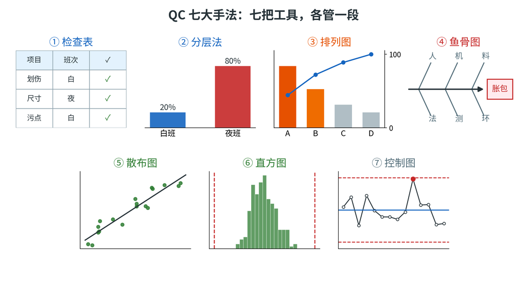

| 阶段 | 工具 | 回答什么 |
| --- | --- | --- |
| 收集→分解 | 检查表、分层法 | 该记哪些项；平均数背后是谁在拉高 |
| 排序 | 排列图 | 先改哪一类 |
| 追因 | 因果图＋5Why | 原因在哪、能不能改 |
| 验证 | 直方图、散布图、控制图 | 形状、关系、稳定性 |

- **怎么选**：七手法管现场数据，五大工具管体系证据——先定问题再选图；七张图一起上，等于没有分析。
- 口诀：查检集数据、层别作解析、柏拉抓重点、鱼骨追原因、直方显分布、散布看相关、管制找异常（柏拉＝排列图，管制＝控制图）。

**记住：七手法按“收集→排序→追因→验证”四段分工，各管一段、不抢活。**

## 检查表：先定项目，再定记录方式

- 定义：用简单、标准化的表格记录数据，便于统计、分析与对比
- 两类：**记录用**收集数据；**点检用**确认设备与作业状态
- 设计五要点：迅速准确、便于记号、考虑分层、来源清楚、项目 4–6 项
- 制作五步：定目的 → 从鱼骨图选 4–6 项 → 定全检或抽检 → 定基准与记录人 → 设计表格
- 表头五要素：检查人、时间、方法、班次、机台，缺一项就无法追溯
- 判读：划伤一项占四成，先追问它发生在哪道工序

| 不良项目 | 合计（件） | 占比 |
| --- | --- | --- |
| 划伤 | 20 | 40.8% |
| 尺寸偏差 | 12 | 24.5% |
| 变形 | 10 | 20.4% |
| 污点 | 7 | 14.3% |
| 合计 | 49 | 100% |

## 分层法：让平均数背后的差异显形

- 定义与目的：按人、机、料、法、测、时、环分类，把“一锅粥”的平均数拆成可比较的组
- 判据：层内变异小、层间差异大，分层才有意义
- 三个分层不足的信号：直方图双峰、控制图连串报警、排列图各类占比相近
- 纪律：一次只分一个维度，分完要能落到“谁去改”

| 维度 | 分层依据 | 现场用法 |
| --- | --- | --- |
| 人 | 年龄、教育程度、性别、班组 | 新员工与老员工对比 |
| 机 | 设备型号、新旧、产线、夹具 | 机台号分开统计 |
| 料 | 产地、批号、厂家、规格 | 按批次追查 |
| 法 | 工艺要求、参数、操作方法 | 两套参数对比 |
| 测 | 设备、方法、人员、取样 | 换测量员复测 |
| 时 | 班次、日期、上午与下午 | 白班与夜班对比 |
| 环 | 照度、温度、湿度 | 夏季与冬季对比 |

## 排列图：抓少数关键，改善前后各画一张

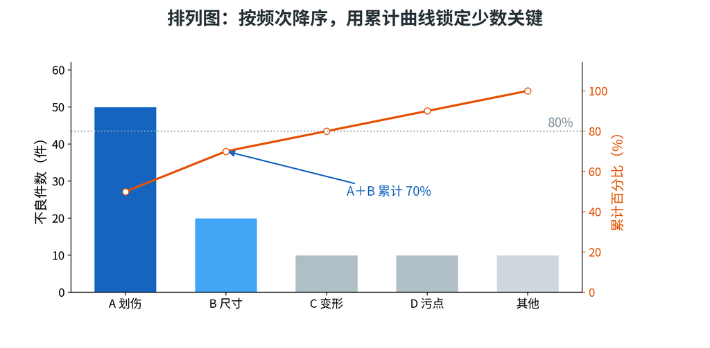

- **是什么**：按频次降序的柱＋累计百分比折线；看的是“前几类一共占了多少”
- **为什么**：资源有限，先改占比最大的两三类，整体指标才动得明显；二八法则是经验规律，各类占比相近时排列图失效，正说明要重新分层
- **怎么判断**：前两类累计 ≥ 60%—70% 才算“少数关键”；改善前后各画一张，总不良下降＋累计线下移＋排在前面的类别换了，三条同时成立才算闭环——只报“不良率降了”会被总量变化骗

## 因果图（鱼骨图）：先把六支铺满，再用数据收敛

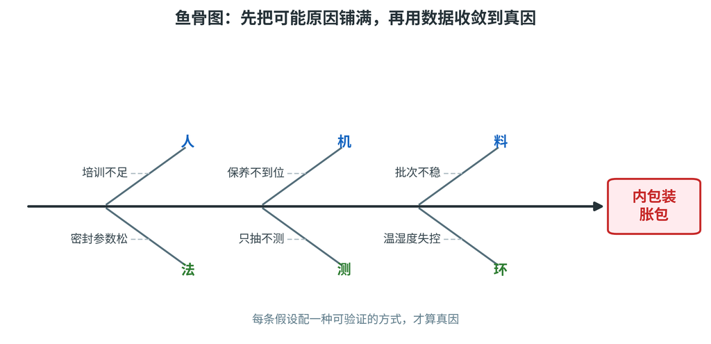

- **是什么**：右端写问题特性，主干挂人、机、料、法、测、环六支，每支再挂可行动的小骨；六支是防漏清单，答题按教材五支（测并入法）
- **为什么**：头脑风暴的价值在“铺满”——它产出的是待验证的假设，不是真因
- **怎么判断**：每条小骨都要能对应一个可观察的量、一种验证方式；没有验证方式的原因，写上去也没人改
- 三条纪律：末端停在“能改的那一层”；发散不评价、收敛只认证据；去掉后消失、加回后重现，才算真因

## 因果图案例：胀包问题的六支展开

**问题特性写在右端：内包产品在保质期内出现胀包；每条原因后面必须跟一种验证方式。**

| 支 | 候选原因 | 验证方式 |
| --- | --- | --- |
| 人 | 未按流程、流动性大、操作不细致 | 查录像与培训记录 |
| 机 | 保养不到位、清洗消毒不足、配件老化 | 拆检、清洗记录、微生物取样 |
| 料 | 批次不一致、桶未清洗、超保质期 | 查批次台账与保质期 |
| 法 | 清洗消毒周期、密封参数、监督责任 | 查作业指导书与点检表 |
| 测 | 只抽不测、记录缺失 | 加做微生物与密封性检测 |
| 环 | 物与料未分开、臭氧消毒不足、密封性差 | 现场走线、压差与密封检查 |

- 判据：去掉后消失、加回后重现，才算真因；对策落到清洗周期、密封点检、批次先进先出

## 直方图：三步作图，四问读图

- **是什么**：把一段时间的数据按组距分箱，看形状、中心与离散
- **三步**：定组数（$K\approx1+3.322\lg n$）→ 算组距（$C=R/K$，向上取到测量单位）→ 定组界（从最小值下侧半格起算）
- **为什么**：直方图看不出时间顺序，异常会被平均掉，所以必须配控制图一起看
- **四问**：形状是否单峰对称？中心是否对准规格中心？宽度是否留余量？有无超差？
- 判读顺序不能反：先看形状，再对规格——形状异常时算出的能力没有意义

| 型态 | 现场含义 |
| --- | --- |
| 双峰 | 两批料、两个班次混在一起 |
| 绝壁 | 数据被剔除，或全检后截断 |
| 离岛 | 异常品混入或测量错误 |

## 直方图案例：把分布叠到规格线上

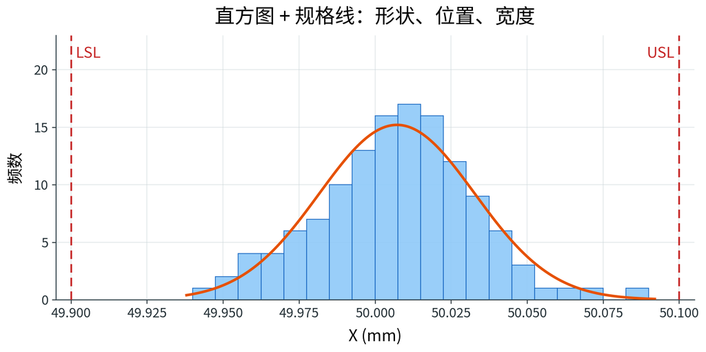

- 图上有四样东西：柱、规格线、拟合曲线、坐标刻度；规格 $50.000\pm0.100$ mm
- 形状：单峰、近似正态；左尾略厚，几根低柱高出拟合线
- 位置与宽度：峰值偏右；数据 49.94～50.09 mm，未触规格线
- 判读：能力有余量，但“有余量”不等于“受控”——三个追问：左尾为何偏厚、中心为何偏、余量是否被浪费

## 散布图：形态、相关系数与分层反转

- **用途**：研究两个变量是否有关系、关系有多强；四种形态：正相关、负相关、不相关、曲线相关；习惯横轴放原因、纵轴放结果
- **画法**：定变量 → 收 ≥30 组（100 组更好）→ 定坐标 → 描点 → 标注 → 判读
- 相关系数 $r=\dfrac{\sum(x_i-\bar x)(y_i-\bar y)}{\sqrt{\sum(x_i-\bar x)^2\sum(y_i-\bar y)^2}}$，$-1\le r\le1$；$|r|$ 越接近 1 线性关系越强，曲线相关会被低估
- **三条纪律**：样本要够、先分层、相关不等于因果；验证因果靠试验设计或工艺机理

| 组 | 温度范围（℃） | 硬度范围（HRC） | 相关系数 |
| --- | --- | --- | --- |
| A 线 | 840–890 | 52.0–56.2 | 0.998 |
| B 线 | 800–850 | 58.0–61.5 | 0.999 |
| 合并 | 800–890 | 52.0–61.5 | $-0.42$ |

- **案例**：合并看是负相关，分层后两条线都是强正相关——整体相关方向由组间差异决定，不是工艺规律

## 七手法与五大工具：谁给谁供数据

- 五大工具是**体系层**：规定什么时候做什么、留下什么证据
- 七手法是**数据层**：把证据做出来、看懂
- 一条链：APQP 定特性 → FMEA 找风险 → MSA 保数据可信 → SPC 看守 → PPAP 交证据
- 常见错位：只做工具文件不做数据，或只做数据不进体系
- 判断企业是否真在用：看控制图有没有反应计划，看 FMEA 有没有数据支撑

| 五大工具 | 主要调用的手法 | 手法提供什么 | 接口产物 |
| --- | --- | --- | --- |
| APQP | 检查表、排列图、因果图 | 顾客要求与历史问题的排序 | 特性清单、风险输入 |
| FMEA | 因果图、排列图 | 失效模式与原因的假设 | 失效模式与原因清单 |
| MSA | 直方图、控制图、散布图 | 测量数据的分布与稳定性 | GR&R 判读 |
| SPC | 控制图、直方图、分层法 | 受控状态与能力证据 | 控制计划、反应计划 |
| PPAP | 检查表、直方图、控制图 | 批量一致性的证据 | 提交证据包 |

## 选用决策表：先问目的，再选工具

- 顺序原则：先“看清楚”，再“找原因”，最后“下结论”
- 一个工具只回答一个问题；回答不了就换工具，不要硬套
- 用法：把它当工具箱索引，立项或答题时先查这张表

| 你面对的问题 | 先用 | 判据或产出 |
| --- | --- | --- |
| 数据还没收集 | 检查表 | 项目 4–6 项、可追溯 |
| 数据混在一起 | 分层法 | 层内小、层间大 |
| 问题太多要排优先级 | 排列图 | 累计 80% 落在哪几项 |
| 知道问题不知道原因 | 因果图加 5Why | 末端可行动、可验证 |
| 想看分布与规格的关系 | 直方图 | 形状、中心、宽度、超差 |
| 想看两个变量的关系 | 散布图 | 形态与 $r$，先分层 |
| 想看随时间是否稳定 | 控制图 | 出界、链、趋势 |
| 要判断一批收不收 | 抽样与 OC 曲线 | $\alpha$、$\beta$、接收概率 |

## 抽样检验：全检不可能时的统计推断

- 场景：破坏性检验、批量大、成本高 → 只能抽一部分推断整批；抽样结论只对“批”负责，不对单件负责
- 三个基本量：批量 $N$、样本量 $n$、判定数 $c$（不合格数 ≤ c 则接收）
- 判读：同一方案对不同不合格品率 $p$ 的接收概率不同 → OC 曲线；全检也不等于零缺陷，漏检、疲劳、方法灵敏度都会让不良品逃逸

| 维度 | 全检 | 抽样 | 判据 |
| --- | --- | --- | --- |
| 适用 | 关键特性、批量小、可全测 | 破坏性、批量大、成本高 | 检验是否破坏产品 |
| 成本 | 单件成本乘批量 | 样本成本加风险成本 | 批量越大抽样越划算 |
| 风险 | 漏检与疲劳，仍有逃逸 | $\alpha$ 与 $\beta$ 两类风险 | 风险能否被接受 |
| 前提 | 检验方法可靠 | 批内均匀、随机抽样 | 批是否同质 |

- **怎么判断**：先问“批是否同质、检验会不会破坏产品”，再谈方案；安全与法规特性往往全检加防错，批不同质时抽样没有意义

## 抽样风险 α／β 与 AQL 抽样方案

- **两类错误**：把好批判坏（$\alpha$，生产方风险，常用 5%），把坏批判好（$\beta$，使用方风险，常用 10%）；与假设检验同构（$H_0$ 为”批合格”，$\alpha$ 弃真、$\beta$ 存伪）
- **谁承担**：$\alpha$ 由供方承担、$\beta$ 由顾客承担；放宽 AQL 只是降低验收门槛，$\beta$ 反而变大，风险转给顾客
- **AQL**：接收质量限，连续批提交时允许的最差过程平均质量水平；它不是”允许的不良率”，而是抽样方案的输入参数
- **判定规则**：不合格数 $\le Ac$ 接收、$\ge Re$ 拒收；方案写成 $[n,\ Ac,\ Re]$，如 $[50,\ 1,\ 2]$；查表：定批量与检验水平 → 样本字码 → 按 AQL 与严格度查 $n$、$c$
- **检验水平与严格度**：一般水平 I／II／III（II 最常用）、特殊水平 S-1～S-4；严格度正常、加严、放宽三档，按转移规则切换
- **常见错误**：不随机抽样、把 AQL 当质量目标、忽略检验水平

## 例题：OC 曲线与抽样 —— 题干与思路

> 练什么：按二项分布算一个计数抽样方案的 $\alpha$、$\beta$ 与 $AOQ$，并说清批量与样本量的口径。

| 参数 | 数值 | 单位 | 口径 |
| --- | --- | --- | --- |
| 样本量 $n$ | 50 | 件 | 每批抽取 |
| 判定数 $c$ | 1 | 件 | 不合格数 $\le1$ 接收、$\ge2$ 拒收 |
| AQL（可接受质量水平） | 1% | 无量纲 | 生产方风险点 $p_1$ |
| LTPD（批容许不合格品率） | 5% | 无量纲 | 使用方风险点 $p_2$ |
| 批量 $N$ | 未给 | 件 | 按连续批、$n/N\le10\%$ 处理 |

- **求**：①$L(1\%)$ 与 $\alpha$（%，保留 1 位）；②$L(5\%)$ 与 $\beta$；③$AOQ$ 的最大值（%，保留 2 位）与对应 $p$（%，保留 1 位）。
- **公式**：$L(p)=\sum_{d=0}^{c}\binom{n}{d}p^d(1-p)^{n-d}$（$L$ 为接收概率、无量纲；$p$ 为批不合格品率，无量纲；$d$ 为样本中不合格件数，件），$\alpha=1-L(1\%)$、$\beta=L(5\%)$、$AOQ=p\,L(p)$。
- **路线**：①先判口径（二项还是超几何） → ②算 $L(1\%)$ 与 $\alpha$ → ③算 $L(5\%)$ 与 $\beta$ → ④试算求 $AOQ$ 最大点。

## 例题：OC 曲线与抽样 —— 分步解答

**第 1 步 定口径与公式**：批量 $N$ 远大于 $n$（连续批，$n/N\le10\%$），用二项分布；若 $N$ 已知且 $n/N>10\%$，改用超几何 $L(p)=\sum_{d=0}^{c}\frac{\binom{D}{d}\binom{N-D}{n-d}}{\binom{N}{n}}$（$D$ 为批中不合格件数，件）。

**第 2 步 求 $L(1\%)$ 与 $\alpha$**：$L(0.01)=\binom{50}{0}0.99^{50}+\binom{50}{1}0.01\times0.99^{49}=0.6050+50\times0.01\times0.6111=0.6050+0.3056=0.9106$，$\alpha=1-0.9106=8.9\%$。

**第 3 步 求 $L(5\%)$ 与 $\beta$**：$L(0.05)=0.95^{50}+50\times0.05\times0.95^{49}=0.0769+2.5\times0.0810=0.0769+0.2025=0.2794$，$\beta=27.9\%$。

**第 4 步 求 $AOQ$ 最大值**：$AOQ(p)=p\,L(p)$，在 $p=3.2\%$ 取最大；$L(0.032)=0.968^{50}+50\times0.032\times0.968^{49}=0.1967+0.3251=0.5218$，$AOQ=0.032\times0.5218=0.0167=1.67\%$。

**判读**：方案执行得再好，出厂批平均仍带 1.67% 的不良（$AOQ$），且 5% 的坏批有 27.9% 被接收（$\beta$）；要降低只能增大 $n$ 或减小 $c$，用成本换判别力。

**易错点/验算**：$\beta=L(5\%)$ 是“接收坏批”的概率，不是 $1-L(5\%)$；AQL 不是“允许 1% 不良”，而是抽样方案的输入参数。

## 可靠性：三规定、指数分布与 MTBF

- **定义**：产品在**规定条件**下、**规定时间**内完成**规定功能**的能力；三个”规定”缺一不可，条件变了、时间变了，可靠度就不可比
- $R(t)=P(T>t)$、$F(t)=1-R(t)$、失效率 $\lambda(t)=f(t)/R(t)$；指数分布（$\lambda$ 为常数）：$R(t)=e^{-\lambda t}$，且 $MTBF=1/\lambda$

公式

$$R(t)=\exp\left(-\int_0^t\lambda(u)\,\mathrm{d}u\right),\qquad MTBF=\frac{1}{\lambda}$$

- 算例：$\lambda=2\times10^{-5}\ \mathrm{h^{-1}}$ → $MTBF=5\times10^{4}\ \mathrm{h}$；工作 1000 h 可靠度 0.980；连续运行一年 8760 h 可靠度 0.839；中位寿命 3.47×10⁴ h
- MTTF 用于不可修产品、MTBF 用于可修产品；串联系统三个 $R=0.98$ 的部件，$R_s=0.98^3=0.941$
- 结论：MTBF 是平均值，不是保证寿命；一半失效会早于中位寿命

## 浴盆曲线：三阶段与质量-可靠性衔接

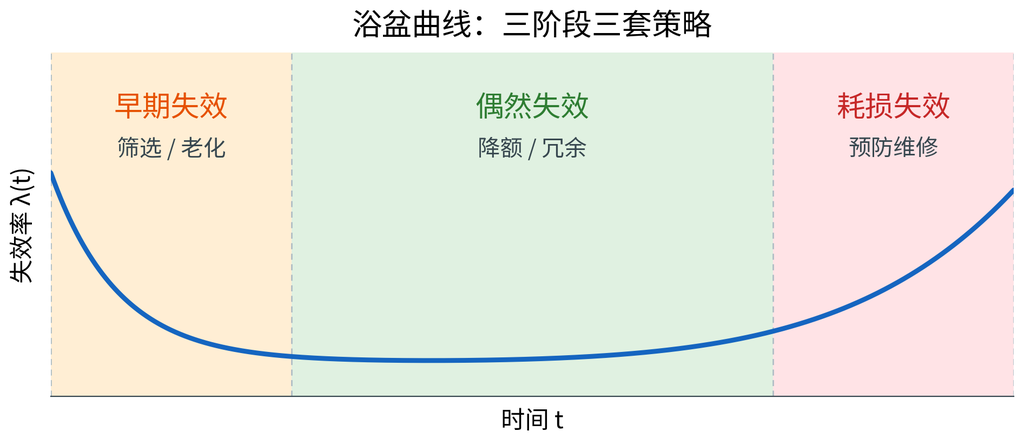

- **早期失效期**：失效率下降，源于设计／制造／装配缺陷；对策＝筛选、老化
- **偶然失效期**：失效率近似常数，源于随机过应力；对策＝可靠性设计、降额、冗余
- **耗损失效期**：失效率上升，源于磨损、疲劳、老化；对策＝预防维修与定期更换
- **两个提醒**：电子件常近似常数失效率；早期段与制造质量相关、耗损段与设计维护相关；质量看”此刻合格”、可靠性看”以后能用”

## 可靠性设计：串联、冗余与降额

- 串联：$R_s=\prod R_i$；三个 0.98 串联只有 0.941，环节越多越不可靠
- 并联：$R_s=1-\prod(1-R_i)$；两个 0.9 并联得 0.99，三个得 0.999
- 设计顺序：先简化与降额，再考虑冗余；冗余不能替代根因消除
- 可靠性工作要前移：设计阶段决定了大部分固有可靠性

| 途径 | 做法 | 效果（示例） | 代价 |
| --- | --- | --- | --- |
| 简化 | 减少零件数与接插件 | 串联环节越少，$R_s$ 越高 | 功能集成难度 |
| 降额 | 元件工作在额定值的 50%～80% | 降低失效率 | 体积与成本 |
| 冗余 | 并联、备用、表决 | 两个 0.9 并联得 0.99 | 成本、重量、复杂度 |
| 筛选 | 老化、环境应力筛选 | 剔除早期失效 | 工时与设备 |
| 维修 | 预防性更换、状态监测 | 延缓耗损期失效 | 停机成本 |

## 从可靠性到随机过程：泊松计数与马尔可夫状态

> 上一页把可靠性拆成串联、冗余与降额；这一页把“随机”写成可算的模型。
- 可靠性用指数分布假设失效率恒定：$R(t)=e^{-\lambda t}$，平均寿命 $MTBF=1/\lambda$
- **泊松过程**：单位时间内的缺陷或故障计数——$\lambda t$ 是期望件数，$P(N=k)=\dfrac{(\lambda t)^k e^{-\lambda t}}{k!}$
- 算例：$\lambda=0.2$ 件/h、$t=8$ h，$\lambda t=1.6$；$P(0)=e^{-1.6}=0.2019$，至少 1 件 $=1-0.2019=0.7981$
- **马尔可夫链**：下一状态只看现在（无后效性）；两状态阵 $\begin{bmatrix}0.98&0.02\\0.3&0.7\end{bmatrix}$ 表示“正常→故障 0.02、故障→正常 0.3”
- 稳态可用率：$\pi_{\text{正常}}=\dfrac{0.3}{0.02+0.3}=0.9375$，即长期 93.75% 的时间在正常状态
- 用途分工：缺陷与故障计数用泊松；设备状态与维修用马尔可夫；排队与产能在制品用 M/M/1

**结论：泊松管“来多少”，马尔可夫管“处在哪”；两者把质量与可靠性从定性判断变成可算的概率。**

## 质量改进的组织：QC 小组、DMAIC 与 PDCA

- **组织三级**：质量委员会（定目标、配资源、评审）→ 质量部门（建体系、内审、协调）→ QC／跨职能小组（选题、查因、对策、验证）
- **QC 小组**：一线员工自愿组成，按 PDCA 活动；程序：选题 → 现状 → 目标 → 原因 → 对策 → 效果 → 标准化
- **六西格玛**：DMAIC 五阶段，分倡导者、黑带、绿带；对应：选题与现状对 D 与 M，原因对 A，对策对 I

| 阶段 | 主要手法 | 产出 |
| --- | --- | --- |
| P 策划 | 检查表、分层法、排列图、因果图 | 问题定义、原因假设、优先顺序 |
| D 实施 | 试验、防错、作业标准 | 措施落地 |
| C 检查 | 直方图、散布图、控制图 | 效果验证、过程是否受控 |
| A 处置 | 标准化、控制计划更新 | 巩固成果、预防再发 |

- **现场案例**（教学情景）：某厂 QC 小组把客诉按排列图排序，先改占比 42% 的装配错件，三个月客诉降一档
- 常见失败：选题大、无基线、只开会、不入标准

## 质量工程与智能制造：接口与断点

> 上一页把改进组织落到班组与项目；这一页把整讲工具收回到课程主线：智能制造放大质量工程，但不替它做判断。
- **接口一 数据底座**：控制计划定特性、样本量与频次，MES 按频次采集，SPC 才有连续数据；手抄记录只能事后补图
- **接口二 全程追溯**：原材料批次→工序参数→检验记录→成品序列号串成一条链，能回答“用了哪批料、谁检的”
- **接口三 体系断点**：数据链断在哪，体系就漏在哪——未做 MSA、临时更改未回滚、无控制计划，系统能列成清单
- **定制化的变化**：小批量打破“同质批”前提，抽样推断变弱，转向在线检测、动态控制计划与更快的 FMEA 更新
- **反例与顺序**：上了 MES 仍用纸质 FMEA 与 CP，只是把纸换成电子档；先理顺 FMEA→CP→MSA→SPC 再谈数字化
- **三条判据**：断点能否被数据发现、闭环能否在批次流出前完成、追溯能否定位到单件

**结论：智能制造给质量工程一副望远镜和一台记录仪；但“能不能放行、敢不敢签字”仍是人的判断。**

## 内容块 4 小结：七手法、抽样与可靠性

- **七手法各管一段**：收集、分解、排序、追因、看形、看关系、看守
- **一条主线**：数据 → 分层 → 排序 → 追因 → 验证 → 标准化
- **抽样三件事**：方案（$n$、$c$）、风险（$\alpha$、$\beta$）、曲线（OC）
- **可靠性三件事**：定义（三规定）、模型（指数分布与 MTBF）、设计（串联与冗余）
- **改进三件事**：组织（QC 小组）、方法（DMAIC）、闭环（PDCA 与标准化）
- 三个数要记住：$\alpha=8.9\%$、$\beta=27.9\%$（$n=50,c=1$）、三个 0.98 串联得 0.941

**工具给结论，责任给人**：任何一张图、一条曲线，都要有人对判读与措施负责。

# 第五部分 · 例题、讨论与 AI 提问

- 真题解析：Cpk＝1.45 判读、五大工具给分点、8D 五步骤（第 7 讲展开）
- 例题：两台车床数据算 Cpk；同一 RPN 的两条失效模式
- 讨论：测量系统不可信时 Cpk 可信吗；控制图报警之后怎么办
- 伦理讨论：FMEA 的预见责任与 SPC 的诚实

## 历年真题：第 2 讲相关题分布

- 六卷（2020 A／B、2021 A／B、2022 A／B）结构一致：单选 30 分、简答 30 分、论述 30 分、计算 10 分

| 考点 | 题型·分值 | 出现卷次 | 复习落点 |
| --- | --- | --- | --- |
| Cpk＝1.45 判读 | 单选 3 分 | 六卷全有 | 背区间，先定位再换算 |
| 五大工具辨析 | 单选 3 分 | 2020 A、2021 A、2022 A | SWOT 不是工具 |
| 体系认证归属 | 单选 3 分 | 2020 B、2021 B、2022 B | 质量认证是 ISO 9000 |
| 五大工具简答 | 简答 5 分 | 2020 B、2021 A、2022 A | 名称＋一句话功能 |
| 8D 五个步骤 | 简答 5 分 | 2020 A／B、2021 A、2022 A | 步骤名＋一句话内容（第 7 讲讲） |
| 人机料法环鱼骨图 | 论述 10 分 | 六卷全有 | 五个分支＋主因排序 |

- 第 2 讲直接分值 **6—16 分**；把鱼骨图 10 分计入，单卷 16—26 分
- Cpk 只考判读、不考手算；2022 A 卷有 6 题／9 题两版，两版都练才不漏；8D 真题在第 7 讲展开

## 真题：Cpk＝1.45 判读完整解析

**题干**（2020—2022 六卷同题，单选 3 分）：工厂的过程能力指数 $C_{pk}=1.45$，代表（ ）

- A 无缺点、考虑降低成本 B 状态良好、维持现状 C 改进为 A 级 D 制程不良较多
- A 项是 A+ 级（$\ge 1.67$）的处置：1.45 距 1.67 还差 0.22，谈不上“能力富余”
- B 项是 A 级（$1.33\le C_{pk}\lt 1.67$）的处置：1.45 正落此区间 → **答案 B**
- C 项是 B 级（1.00—1.33）的处置：把低一级的动作套到 A 级，错位一级
- D 项是 C 级（0.67—1.00）的处置：与 1.45 差两个等级，直接排除
- 换算校验：$Z=3\times1.45=4.35$，双侧 $2\Phi(-4.35)\approx 13.6$ ppm，不是“无缺点”
- 四步答题：定位区间 → 逐项排除 → 换算量级 → 补前提

> 判读表只回答“等级”，不回答“为什么”；理由要自己补上。

## 真题：五大工具简答的给分点

**题干**（2020 B 二.7、2021 A 二.5、2022 A 二.8，5 分）：列举质量体系五大工具并简述其内容

- 给分：5 个工具 × 1 分 ＝ 名称 0.5 分 ＋ 一句话功能 0.5 分；少写一个就少 1 分

| 工具 | 一句话功能（得分点） | 常见扣分 |
| --- | --- | --- |
| APQP & CP | 先期策划，输出控制计划，把质量提前设计进去 | 只写 APQP，漏掉 CP |
| FMEA | 事前找失效模式，评 S／O／D，定预防与探测措施 | 写成“事后分析原因” |
| MSA | 先证明量具可信：重复性、再现性、偏倚、线性 | 只写“测量”，不写“系统” |
| SPC | 用控制图区分普通原因与特殊原因，稳定后再算能力 | 与 Cpk 混为一谈 |
| PPAP | 用证据包向顾客申请量产放行，PSW 只是承诺书 | 与 APQP 写反 |

- 记忆锚：**策划 → 预见 → 量得准 → 控得住 → 放行**
- 串联：APQP 出控制计划 → 控制计划定 MSA 与 SPC 的对象 → PPAP 收口
- 常混：8D、QC 七大手法、ISO 9001 都不是五大工具，答题时不要凑数

## 例题：两台车床数据算 Cpk —— 题干与思路

> 练什么：先用合并样本算 $C_{pk}$，再按机台分层重算，判断“能力不足”是精度不够还是基准不一致。

| 已知 | 数值 |
| --- | --- |
| 规格 | $25.000\pm0.050$ mm，即 USL＝25.050 mm、LSL＝24.950 mm，$T=0.10$ mm |
| A 机（5 件） | 24.978、24.992、24.985、24.990、24.980（mm） |
| B 机（5 件） | 25.022、25.008、25.015、25.010、25.020（mm） |
| 判读门槛 | C 级 0.67～1.00、B 级 1.00～1.33、A+ 级 ≥1.67 |

- **求**：①合并样本的 $\bar X$ 与 $s$（mm，保留 4 位）；②合并样本的 $C_{pk}$ 与等级；③分层后两线 $C_{pk}$ 与统一基准后的 $C_{pk}$。
- **公式**：$s=\sqrt{\sum(x_i-\bar X)^2/(n-1)}$、$C_p=T/(6s)$、$C_{pk}=\min(USL-\bar X,\ \bar X-LSL)/(3s)$；其中 $x_i$ 为单件测量值（mm），$n=10$ 为件数，$T$ 为公差宽度（mm），$USL$／$LSL$ 为上／下规格限（mm），$s$ 为标准差（mm），$C_p$／$C_{pk}$ 为能力指数（无量纲）。
- **路线**：①合并 10 件求 $\bar X$ 与 $s$ → ②算合并 $C_{pk}$ 并定级 → ③按机台分层各求 $s$ 与 $C_{pk}$ → ④比较均值差与波动，算统一基准后的 $C_{pk}$。

## 例题：两台车床数据算 Cpk —— 分步解答

**第 1 步 合并样本的均值与 $s$**：$\sum x_i=250.000$ mm，$\bar X=25.000$ mm；偏差 $d_i$（mm）＝−0.022、−0.008、−0.015、−0.010、−0.020、+0.022、+0.008、+0.015、+0.010、+0.020，$\sum d_i^2=0.002546$，$s=\sqrt{0.002546/9}=\sqrt{0.000283}=0.0168$ mm。

**第 2 步 合并样本的 $C_{pk}$**：$T=0.10$ mm，$C_p=0.10/(6\times0.0168)=0.99$；均值正对中心，$C_a=0$，$C_{pk}=C_p=0.99$，属 C 级（0.67～1.00）。

**第 3 步 分层重算**：$\bar X_A=124.925/5=24.985$、$\bar X_B=125.075/5=25.015$ mm；$s_A=s_B=\sqrt{0.000148/4}=0.00608$ mm；两线 $C_{pk}=\min(0.065,\ 0.035)/(3\times0.00608)=1.92$，属 A+ 级。

**第 4 步 找机制**：两线均值差 $\Delta=0.030$ mm＝30 μm，是组内 $\sigma$ 的约 5 倍；合并方差 $0.002546/9=0.000283$ 中，设备间偏移项占 $0.000250$（约 88%），组内波动项只占 $0.000033$。

**判读**：统一两线对刀基准把 $\Delta$ 压到零，$C_{pk}=0.050/(3\times0.00608)=2.74$；C 级不是“精度差”，而是“基准不一致”——先分层、看直方图，再谈能力。

**易错点/验算**：合并样本是双峰，$C_{pk}=0.99$ 只是按单一正态的折算，前提不成立；0.99 按正态约 0.3% 不良（约 3000 ppm），10 件全合格并不奇怪。

## 例题：同一 RPN 的两条失效模式

**已知**：两条失效模式的评分如下

| 失效模式 | S·O·D | RPN | 后果定位 | 优先行动 |
| --- | --- | --- | --- | --- |
| 安全件漏装 | 9·4·5 | 180 | 危及人身安全 | 立即整改：防错＋100% 检测 |
| 外观划伤 | 3·10·6 | 180 | 影响交付与成本 | 列入改善计划 |

- 问题：RPN 相同，为什么不能按同一优先级处理？
- 解：RPN 是乘积，掩盖了 S 的差异；AP 以 S 为第一判据，安全后果优先
- 结论：**先看 S 是否触及安全／法规，再比较 O、D 与 RPN**
- 延伸：不能立即整改时，先加临时探测措施，再排永久措施

## 课堂讨论 1：测量系统不可信，Cpk 可信吗

- 场景：某工序 Cpk＝1.45，但量具的 GR&R＝35%
- 问题 1：这个 1.45 能作为量产放行依据吗？为什么？
- 问题 2：GR&R 偏大时，Cpk 会被高估还是低估？取决于什么？
- 讨论线索：$\sigma_{obs}^2=\sigma_{proc}^2+\sigma_{ms}^2$，量具差时观测波动被放大
- 结论方向：先把测量系统修到可接受，再谈过程能力

## 课堂讨论 2：控制图报警之后怎么办

- 场景：X̄ 图某点超出 UCL，当班班组正在赶产
- 第一步：确认数据——录入、量具、取样是否有误
- 第二步：查现场——人、机、料、法、环逐项排查，隔离可疑品
- 反例：直接改控制限、剔除数据点，把报警“消掉”
- 讨论：查明是特殊原因并消除后，控制限要不要重算？
- 结论方向：特殊原因消除后，用受控数据重算；不能靠改限掩盖异常

## 伦理讨论：工具是对社会的承诺

- **FMEA 的每一行**都在回答：这个失效会发生什么后果、我们准备承担吗；把 S 调低、把 D 调高来”让 RPN 好看”，就是提前推卸责任
- **SPC 报警后的选择**暴露质量文化：查原因，还是剔除不利数据、放宽控制限、把特殊原因写成普通原因
- **凯悦案**（第 1 讲）：设计变更后吊杆节点荷载由 89 kN 增到 178 kN，没有设计验证与复核去拦截——本讲的 FMEA、设计验证、控制计划，正是”预见与拦截”的制度化
- 一句提醒：文件可以后补，后果不会；数据可以说谎，产品不会
- **讨论**：① 你见过哪些”把 S 调低”的做法？② 报警后若领导要求”先放行”，你的下一步是什么？

# 第六部分 · 本讲小结、作业与下讲预告

- 三句话小结
- 关键概念清单（20 个术语）
- 作业：概念、计算与分析（100 分）
- 下讲预告：工业工程与精益生产；课后阅读与预习

## 本讲小结：三句话收束全讲

1. **五大工具是一条证据链**：APQP 定框架、FMEA 找风险、控制计划定控制点、MSA 保数据、SPC 判稳定、PPAP 收口；前一环的输出是后一环的输入。
2. **过程能力把“稳不稳”变成“够不够”**：$C_p$ 看精度、$C_a$ 看准度、$C_{pk}$ 合成两者；1.33 与 1.67 是两道门槛，ppm 是把能力翻译成顾客听得懂的语言。
3. **QC 七大手法、抽样与可靠性补上“怎么看”**：检查表、分层、排列图找问题，因果图、散布图找原因，直方图、控制图看分布与稳定；抽样有风险，可靠性看寿命分布。

> 工具给出证据，判读给出结论，责任决定证据要不要说真话。
- 自测：合上笔记，用 90 秒复述三句话，每句补一个本讲的数字或案例。
- 主线回收：工具 → 数据 → 判读 → 责任；下一页用 20 个术语做清单式回收。
- 过渡：质量回答“别做坏”，下一讲回答“别白做”。

## 关键概念清单：20 个术语

| 工具链 | 风险语言 | 数据与判读 | 判异与指数 |
| --- | --- | --- | --- |
| APQP | DFMEA | RPN | 判异八准则 |
| CP | PFMEA | AP | $C_p$ |
| PPAP | 严重度 S | GR&R | $C_{pk}$ |
| MSA | 频度 O | 普通原因 | AQL |
| SPC | 探测度 D | 特殊原因 | MTBF |

- 四组关系：工具链回答“做什么”，风险语言回答“先做什么”，数据判读回答“凭什么”，判异与指数回答“够不够、何时停”。
- 会算：$C_p$、$C_a$、$C_{pk}$、RPN 与 ppm；会判：判异八准则、1.33／1.67 两道门槛、GR&R 的 10%／30%。
- 抽查：下次课随机抽 5 个术语，各配一句定义和一个现场例子；答不出者回到对应页重看。

## 作业：概念、计算与分析（100 分）

**1. 概念题（20 分）** 辨析五组概念并各举一个现场例子（每组 4 分）：普通原因／特殊原因、控制限／规格限、$C_p$／$C_{pk}$、重复性／再现性、DFMEA／PFMEA。

**2. 计算题（50 分）** 规格 $25.00\pm0.08$ mm，数据见下。求 $\bar X$、$s$、$C_p$、$C_a$、$C_{pk}$，判级并估算 ppm（30 分）；另一过程 $n=5$、25 组（$A_2=0.577$、$D_4=2.114$、$D_3=0$），$\bar{\bar X}=25.030$、$\bar R=0.032$，求 $\bar X$–$R$ 控制限并判断某组均值 25.052 是否报警（20 分）。

**数据**（mm，$n=10$）：25.02、25.04、25.03、25.05、25.01、25.03、25.04、25.02、25.05、25.01。

**3. 分析题（30 分）** 某工序 $C_{pk}=0.92$、GR&R＝38%、控制图连续 3 点超出控制限，车间主张全检出货：① 按“测量系统→过程稳定→能力→控制计划”说明为何不能直接全检（10 分）；② 写一条对应 PFMEA 失效模式，给出 S／O／D 与 AP 判读（10 分）；③ 写出控制计划的反应计划（10 分）。

- 要求与评分：写公式、代值与单位，按步骤给分；分析按“数据—判断—措施”三层写。

## 下讲预告：工业工程与精益生产

| 模块 | 核心内容 | 你要会什么 |
| --- | --- | --- |
| IE 基础 | 对人员、物料、设备、能源和信息的集成系统进行设计、改善、设置 | 说清 IE 与质量工程的分工 |
| 工作研究 | 方法研究（程序、操作、动作分析）＋作业测定（秒表测时、工作抽样、预定时间标准） | 画一张程序分析图 |
| 八大浪费 | 返工、过分加工、多余动作、搬运、库存、过量生产、等待、管理浪费 | 在身边认出三类浪费 |
| 改善工具 | ECRS 与 ESCRI 原则、5W1H 提问法、人机料法环、鱼骨图、PDCA、5S、防错 | 用 ECRS 提一条改善建议 |
| 精益生产 | 价值、价值流、流动、需求拉动、尽善尽美；看板拉动与价值流分析 | 解释库存为何掩盖问题 |

- **主线**：质量讲“别做坏”，工业工程讲“别白做”——同一套现场，用更少的人、料、时间做出同样好的产品。
- **实验 2 课时**：线性规划建模（生产线平衡、人机联合、EOQ），用 Python 求解并写实验报告。
- **伦理落点**：效率与人的关系——自动化对岗位的影响、劳动强度与工作设计。
- 课前准备：带一个身边的浪费例子；装好 Python 与 PuLP，实验课直接用。

## 课后阅读与预习清单

- **复习本讲**：教材第 3 章 3.1 节——质量定义、三阶段、七项原则；回看五大工具关系图、Cpk 算例与 QC 七手法的用途—做法—判读
- **工具材料**：《TS16949：2009 五大核心工具培训》五部分；《APQP 第二版》对照五阶段交付物；重点读判异准则与 PPAP 提交等级
- **标准条款**：ISO/TS 16949:2009 的 7.3.2.2（APQP）、7.3.2.3（特殊特性）、7.3.6（PPAP）、7.5.1.1（控制计划）、7.6.1（MSA）、8.1.1（统计工具）；军标选读 GJB 9001C-2017、GJB 6117-2007、GJB 6387-2008（只读目录）
- **预习教材**：3.2 节——IE 定义与特征、八大浪费、ECRS、工作研究、现场管理与防呆；4.4 节精益生产部分
- **拓展阅读**：Womack & Jones《精益思想》五项原则；价值流图与看板拉动
- **预习问题**：① 为什么说库存是问题的根源？② 用 ECRS 改造你熟悉的一个流程，删掉哪一步？③ 防呆与 FMEA 的接口在哪里？